# Проект: Исследование объявлений продажи квартир и определение рыночной стоимости объектов недвижимости

# Описание проекта

На основе данных сервиса недвижимости определить рыночную стоимость объектов недвижимости в зависимости от различных параметров, влияющих на цену объектов.

**Цели проекта:**

- проанализировать исходные данные;
- определить ключевые параметры, влияющие на стоимость квартир;
- изучить скорость продажи квартир;
- определить зависимость между параметрами и стоимостью квартир;
- определить среднюю стоимость квадратного метра в популярных населенных пунктах;
- исследовать, как расстояние до центра города влияет на стоимость объектов.

# Описание данных

Анализ проведен на основе архива объявлений о продаже квартир в Санкт-Петербурге и соседних населенных пунктов за несколько лет.

В описании каждого объявления о продаже доступны два вида данных:

- внесенные самим пользователем;
- полученные автоматически на основе картографических сведений.

Исходные данные находятся в файле `estate_data.csv`:

- `airports_nearest` — расстояние до ближайшего аэропорта в метрах (м)
- `balcony` — число балконов
- `ceiling_height` — высота потолков (м)
- `cityCenters_nearest` — расстояние до центра города (м)
- `days_exposition` — сколько дней было размещено объявление (от публикации до снятия)
- `first_day_exposition` — дата публикации
- `floor` — этаж
- `floors_total` — всего этажей в доме
- `is_apartment` — апартаменты (булев тип)
- `kitchen_area` — площадь кухни в квадратных метрах (м²)
- `last_price` — цена на момент снятия с публикации
- `living_area` — жилая площадь в квадратных метрах (м²)
- `locality_name` — название населённого пункта
- `open_plan` — свободная планировка (булев тип)
- `parks_around3000` — число парков в радиусе 3 км
- `parks_nearest` — расстояние до ближайшего парка (м)
- `ponds_around3000` — число водоёмов в радиусе 3 км
- `ponds_nearest` — расстояние до ближайшего водоёма (м)
- `rooms` — число комнат
- `studio` — квартира-студия (булев тип)
- `total_area` — общая площадь квартиры в квадратных метрах (м²)

# План проекта

1. Загрузка данных

```
1.1. Загрузка библиотек
1.2. Загрузка данных
```

2. Предобработка данных

```
2.1. Общая предобработка
2.2. Повышение качества данных
	2.2.1. Заполнение пропусков
	2.2.2. Изменение типа данных
2.3. Создание новых столбцов
2.4. Поиск неявных дубликатов
```

3. Исследовательский анализ данных

```
3.1. Поиск и обработка аномальных значений в данных
	3.1.1. Параметр «Общая площадь»
	3.1.2. Параметр «Жилая площадь»
	3.1.3. Параметр «Площадь кухни»
	3.1.4. Параметр «Высота потолков»
	3.1.5. Параметр «Количество комнат»
	3.1.6. Параметр «Количество этажей в доме»
	3.1.7. Параметр «Тип этажа квартиры»
	3.1.8. Параметр «Цена объекта»
	3.1.9. Параметр «Расстояние до центра города»
	3.1.10. Параметр «Расстояние до ближайшего парка»
	3.1.11. Параметр «Дата публикации объявления»
3.2. Анализ влияния параметров на стоимость объектов
	3.2.1. Скорость продажи квартир
	3.2.2. Определение факторов влияющих на общую стоимость
		3.2.2.1. Корреляция между общей площадью и стоимостью
		3.2.2.2. Корреляция между жилой площадью и стоимостью
		3.2.2.3. Корреляция между кухонной площадью и стоимостью
		3.2.2.4. Корреляция между количеством комнат и стоимостью
		3.2.2.5. Корреляция между типом этажа и стоимостью
		3.2.2.6. Корреляция между датой публикации (день недели, месяц, год) и стоимостью
	3.2.3. Средняя цена квадратного метра в 10 населенных пунктах
	3.2.4. Изучим зависимость расстояния до центра города на стоимость объекта
```

4. Заключение

# 1. Загрузка данных

## 1.1. Загрузка библиотек

```python
import pandas as pd
import matplotlib.pyplot as plt
from IPython.display import display
```

## 1.2. Загрузка данных

```python
df = pd.read_csv('estate_data.csv', sep='\t')
```

```python
df.head()
```

|  | total_images | last_price | total_area | first_day_exposition | rooms | ceiling_height | floors_total | living_area | floor | is_apartment | ... | kitchen_area | balcony | locality_name | airports_nearest | cityCenters_nearest | parks_around3000 | parks_nearest | ponds_around3000 | ponds_nearest | days_exposition |
| --- | --- | --- | --- | --- | --- | --- | --- | --- | --- | --- | --- | --- | --- | --- | --- | --- | --- | --- | --- | --- | --- |
| 0 | 20 | 13000000.0 | 108.0 | 2019-03-07T00:00:00 | 3 | 2.70 | 16.0 | 51.0 | 8 | NaN | ... | 25.0 | NaN | Санкт-Петербург | 18863.0 | 16028.0 | 1.0 | 482.0 | 2.0 | 755.0 | NaN |
| 1 | 7 | 3350000.0 | 40.4 | 2018-12-04T00:00:00 | 1 | NaN | 11.0 | 18.6 | 1 | NaN | ... | 11.0 | 2.0 | посёлок Шушары | 12817.0 | 18603.0 | 0.0 | NaN | 0.0 | NaN | 81.0 |
| 2 | 10 | 5196000.0 | 56.0 | 2015-08-20T00:00:00 | 2 | NaN | 5.0 | 34.3 | 4 | NaN | ... | 8.3 | 0.0 | Санкт-Петербург | 21741.0 | 13933.0 | 1.0 | 90.0 | 2.0 | 574.0 | 558.0 |
| 3 | 0 | 64900000.0 | 159.0 | 2015-07-24T00:00:00 | 3 | NaN | 14.0 | NaN | 9 | NaN | ... | NaN | 0.0 | Санкт-Петербург | 28098.0 | 6800.0 | 2.0 | 84.0 | 3.0 | 234.0 | 424.0 |
| 4 | 2 | 10000000.0 | 100.0 | 2018-06-19T00:00:00 | 2 | 3.03 | 14.0 | 32.0 | 13 | NaN | ... | 41.0 | NaN | Санкт-Петербург | 31856.0 | 8098.0 | 2.0 | 112.0 | 1.0 | 48.0 | 121.0 |

5 rows × 22 columns

# 2. Предобработка данных

## 2.1. Общая предобработка

Применим функцию для предварительной обработки данных. Она предоставит нам общую информацию, количество пропущенных значений и количество дубликатов в данных.

```python
def preprocessing(x):
    print('Общая информация:')
    display(x.info())

    print('Количество пропусков:')
    display(x.isna().sum())

    print('Наличие дубликатов:')
    display(x.duplicated().sum())
```

```python
preprocessing(df);
```

```
Общая информация:
<class 'pandas.core.frame.DataFrame'>
RangeIndex: 23699 entries, 0 to 23698
Data columns (total 22 columns):
 #   Column                Non-Null Count  Dtype
---  ------                --------------  -----
 0   total_images          23699 non-null  int64
 1   last_price            23699 non-null  float64
 2   total_area            23699 non-null  float64
 3   first_day_exposition  23699 non-null  object
 4   rooms                 23699 non-null  int64
 5   ceiling_height        14504 non-null  float64
 6   floors_total          23613 non-null  float64
 7   living_area           21796 non-null  float64
 8   floor                 23699 non-null  int64
 9   is_apartment          2775 non-null   object
 10  studio                23699 non-null  bool
 11  open_plan             23699 non-null  bool
 12  kitchen_area          21421 non-null  float64
 13  balcony               12180 non-null  float64
 14  locality_name         23650 non-null  object
 15  airports_nearest      18157 non-null  float64
 16  cityCenters_nearest   18180 non-null  float64
 17  parks_around3000      18181 non-null  float64
 18  parks_nearest         8079 non-null   float64
 19  ponds_around3000      18181 non-null  float64
 20  ponds_nearest         9110 non-null   float64
 21  days_exposition       20518 non-null  float64
dtypes: bool(2), float64(14), int64(3), object(3)
memory usage: 3.7+ MB
```

```
None
```

```
Количество пропусков:
```

```
total_images                0
last_price                  0
total_area                  0
first_day_exposition        0
rooms                       0
ceiling_height           9195
floors_total               86
living_area              1903
floor                       0
is_apartment            20924
studio                      0
open_plan                   0
kitchen_area             2278
balcony                 11519
locality_name              49
airports_nearest         5542
cityCenters_nearest      5519
parks_around3000         5518
parks_nearest           15620
ponds_around3000         5518
ponds_nearest           14589
days_exposition          3181
dtype: int64
```

```
Наличие дубликатов:
```

```
0
```

Построим гистограммы для числовых столбцов. Они помогут нам выявить важные моменты, аномалии и выбросы.

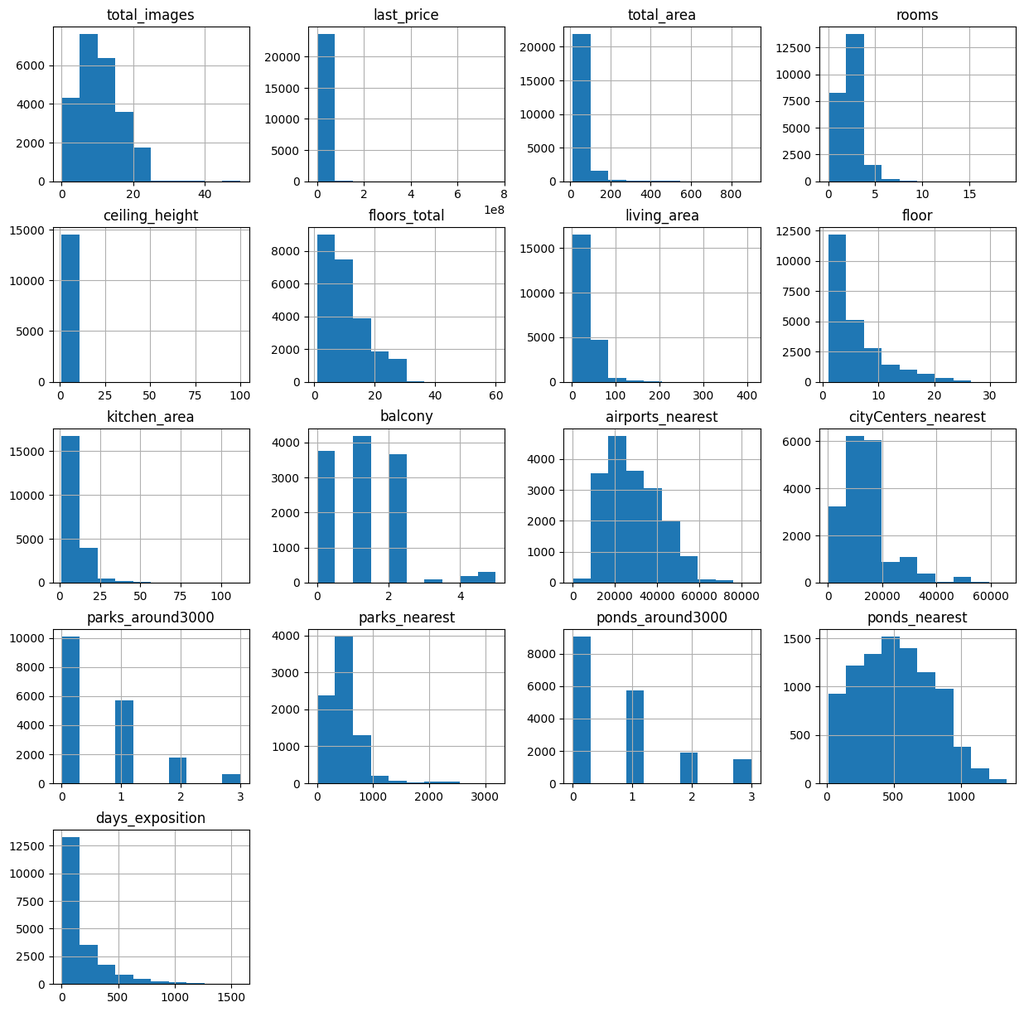

```python
df.hist(figsize=(15, 15));
```

**Вывод по разделу:**

В исходных данных у нас 22 столбца и 23 699 строк. Качество данных — низкое. Уже заметны явные аномалии на графиках, несоответствие типов данных и наличие пропусков в столбцах.

**При обзоре данных обнаружено несоответствие типа данных в 7 столбцах:**

- last_price (цена на момент снятия с публикации) — изменим тип на int;
- parks_around3000 (число парков в радиусе 3 км) — изменим тип на int;
- ponds_around3000 (число водоемов в радиусе 3 км) — изменим тип на int;
- balcony (число балконов) — изменим тип на int;
- is_apartment (апартаменты) — изменим тип на bool;
- days_exposition (сколько дней было размещено объявление) — изменим тип на int;
- floors_total (всего этажей) — изменим тип на int.

Типы данных нужно изменить для исключения ошибок и проблем при проведении анализа.

**Пропуски в данных есть в 14 столбцах из 22:**

**Возможные причины возникновения пропусков:**

Данные в датасете двух видов: внесенные пользователями и полученные автоматически. Ячейки могут быть незаполненными из-за отсутствия информации, указания пустоты как нулевого значения или возможных ошибок при автоматизированной обработке данных.

Наблюдаем несоответствие типа данных в столбцах:

- столбец first_day_exposition имеет тип object вместо datetime;
- столбец floors_total имеет тип float вместо int;
- столбец is_apartment имеет тип object вместо bool;
- столбец balcony имеет тип float вместо int;
- столбец parks_around3000 имеет тип float вместо int;
- столбец ponds_around3000 имеет тип float вместо int;
- столбец days_exposition имеет тип float вместо int.

На графиках мы видим явные аномалии, которые требуют более тщательного изучения.

## 2.2. Повышение качества данных

### 2.2.1. Заполнение пропусков

Установим заглушку и заполним пропуски там, где это возможно.

```python
df['is_apartment'] = df['is_apartment'].fillna(False)

empty_values = ['balcony', 'days_exposition', 'parks_around3000', 'ponds_around3000', 'floors_total']

for row in empty_values:
    df[row] = df[row].fillna(0)

df.isna().sum()
```

```
total_images                0
last_price                  0
total_area                  0
first_day_exposition        0
rooms                       0
ceiling_height           9195
floors_total                0
living_area              1903
floor                       0
is_apartment                0
studio                      0
open_plan                   0
kitchen_area             2278
balcony                     0
locality_name              49
airports_nearest         5542
cityCenters_nearest      5519
parks_around3000            0
parks_nearest           15620
ponds_around3000            0
ponds_nearest           14589
days_exposition             0
dtype: int64
```

Переименуем столбец 'cityCenters_nearest' в соответствии с PEP8.

```python
df = df.rename(columns={'cityCenters_nearest': 'city_centers_nearest'})
```

### 2.2.2. Изменение типа данных

Изменим тип данных во всех столбцах, где это необходимо.

```python
df['is_apartment'] = df['is_apartment'].astype('bool')

change_astype = [
    'days_exposition',
    'balcony',
    'ponds_around3000',
    'parks_around3000',
    'last_price',
    'rooms',
    'floors_total']

for row in change_astype:
    df[row] = df[row].astype('int')
```

```python
df.dtypes
```

```
total_images              int64
last_price                int32
total_area              float64
first_day_exposition     object
rooms                     int32
ceiling_height          float64
floors_total              int32
living_area             float64
floor                     int64
is_apartment               bool
studio                     bool
open_plan                  bool
kitchen_area            float64
balcony                   int32
locality_name            object
airports_nearest        float64
city_centers_nearest    float64
parks_around3000          int32
parks_nearest           float64
ponds_around3000          int32
ponds_nearest           float64
days_exposition           int32
dtype: object
```

Также изменим тип данных в столбце "first_day_exposition" и преобразуем даты в формат: год, месяц, день.

```python
df['first_day_exposition'] = pd.to_datetime(df['first_day_exposition'], format = '%Y-%m-%dT00:00:00')
```

Проверим, все ли данные верны после внесенных изменений.

```python
preprocessing(df)
```

```
Общая информация:
<class 'pandas.core.frame.DataFrame'>
RangeIndex: 23699 entries, 0 to 23698
Data columns (total 22 columns):
 #   Column                Non-Null Count  Dtype
---  ------                --------------  -----
 0   total_images          23699 non-null  int64
 1   last_price            23699 non-null  int32
 2   total_area            23699 non-null  float64
 3   first_day_exposition  23699 non-null  datetime64[ns]
 4   rooms                 23699 non-null  int32
 5   ceiling_height        14504 non-null  float64
 6   floors_total          23699 non-null  int32
 7   living_area           21796 non-null  float64
 8   floor                 23699 non-null  int64
 9   is_apartment          23699 non-null  bool
 10  studio                23699 non-null  bool
 11  open_plan             23699 non-null  bool
 12  kitchen_area          21421 non-null  float64
 13  balcony               23699 non-null  int32
 14  locality_name         23650 non-null  object
 15  airports_nearest      18157 non-null  float64
 16  city_centers_nearest  18180 non-null  float64
 17  parks_around3000      23699 non-null  int32
 18  parks_nearest         8079 non-null   float64
 19  ponds_around3000      23699 non-null  int32
 20  ponds_nearest         9110 non-null   float64
 21  days_exposition       23699 non-null  int32
dtypes: bool(3), datetime64[ns](1), float64(8), int32(7), int64(2), object(1)
memory usage: 2.9+ MB
```

```
None
```

```
Количество пропусков:
```

```
total_images                0
last_price                  0
total_area                  0
first_day_exposition        0
rooms                       0
ceiling_height           9195
floors_total                0
living_area              1903
floor                       0
is_apartment                0
studio                      0
open_plan                   0
kitchen_area             2278
balcony                     0
locality_name              49
airports_nearest         5542
city_centers_nearest     5519
parks_around3000            0
parks_nearest           15620
ponds_around3000            0
ponds_nearest           14589
days_exposition             0
dtype: int64
```

```
Наличие дубликатов:
```

```
0
```

## 2.3. Создание новых столбцов

Основываясь на имеющихся у нас данных, мы можем расширить наши данные полезной и важной информацией для исследования. Рассчитаем и добавим столбцы с данными:

```python
# создадим столбец 'price_area' с ценой за квадратный метр
df['price_area'] = (df['last_price'] / df['total_area']).round(2)

# создадим столбец 'public_week_day' с днем недели публикации объявления (где 0 - понедельник, 1 - вторник и т.д.)
df['public_week_day'] = df['first_day_exposition'].dt.weekday

# создадим столбец 'public_month' с месяцем публикации объявления
df['public_month'] = df['first_day_exposition'].dt.month

# создадим столбец 'public_year' с годом публикации объявления
df['public_year'] = df['first_day_exposition'].dt.year

# столбец 'city_centers_nearest_km' с расстоянием до центра города с округлением
df['city_centers_nearest_km'] = (df['city_centers_nearest'] / 1000).round()
```

```python
# создадим столбец 'type_floor' c типом этажа квартиры («первый», «последний», «другой»)
def type_floor(row):
    floors_total = row['floors_total']
    floor = row['floor']
    if floor == 1:
        return 'первый'
    elif floor == floors_total:
        return 'последний'
    elif 1 < floor < floors_total:
        return 'другой'

df['type_floor'] = df.apply(type_floor, axis = 1)
```

Проверим, все ли созданные столбцы на месте, и убедимся в корректности результатов.

```python
df.sample(5)
```

|  | total_images | last_price | total_area | first_day_exposition | rooms | ceiling_height | floors_total | living_area | floor | is_apartment | ... | parks_nearest | ponds_around3000 | ponds_nearest | days_exposition | price_area | public_week_day | public_month | public_year | city_centers_nearest_km | type_floor |
| --- | --- | --- | --- | --- | --- | --- | --- | --- | --- | --- | --- | --- | --- | --- | --- | --- | --- | --- | --- | --- | --- |
| 6230 | 3 | 4790000 | 45.1 | 2018-07-12 | 1 | 2.68 | 25 | 19.2 | 21 | False | ... | NaN | 0 | NaN | 60 | 106208.43 | 3 | 7 | 2018 | 10.0 | другой |
| 4347 | 13 | 4990000 | 70.0 | 2017-10-04 | 2 | NaN | 8 | 38.0 | 8 | False | ... | NaN | 0 | NaN | 428 | 71285.71 | 2 | 10 | 2017 | NaN | последний |
| 12162 | 11 | 15000000 | 71.2 | 2017-12-12 | 2 | NaN | 12 | 36.0 | 10 | False | ... | 2276.0 | 3 | 244.0 | 208 | 210674.16 | 1 | 12 | 2017 | 11.0 | другой |
| 7569 | 13 | 4450000 | 42.0 | 2018-07-12 | 2 | 2.50 | 9 | 28.0 | 2 | False | ... | NaN | 1 | 636.0 | 66 | 105952.38 | 3 | 7 | 2018 | 12.0 | другой |
| 16147 | 13 | 7600000 | 79.0 | 2018-06-04 | 3 | 3.00 | 4 | 58.0 | 2 | False | ... | 429.0 | 0 | NaN | 156 | 96202.53 | 0 | 6 | 2018 | 12.0 | другой |

5 rows × 28 columns

## 2.4. Поиск неявных дубликатов

Изучим уникальные значения в столбце "locality_name" и выясним количество уникальных населенных пунктов.

```python
display(df.locality_name.value_counts())

print('Количество уникальных населенных пунктов:', df.locality_name.nunique())
```

```
Санкт-Петербург        15721
посёлок Мурино           522
посёлок Шушары           440
Всеволожск               398
Пушкин                   369
                       ...
поселок Каложицы           1
село Никольское            1
поселок Гаврилово          1
деревня Чудской Бор        1
поселок Жилгородок         1
Name: locality_name, Length: 364, dtype: int64
```

```
Количество уникальных населенных пунктов: 364
```

В наших данных 364 уникальных населённых пункта. Составим список этих уникальных названий и внимательно их рассмотрим.

```python
display(df['locality_name'].unique())
```

```
array(['Санкт-Петербург', 'посёлок Шушары', 'городской посёлок Янино-1',
       'посёлок Парголово', 'посёлок Мурино', 'Ломоносов', 'Сертолово',
       'Петергоф', 'Пушкин', 'деревня Кудрово', 'Коммунар', 'Колпино',
       'поселок городского типа Красный Бор', 'Гатчина', 'поселок Мурино',
       'деревня Фёдоровское', 'Выборг', 'Кронштадт', 'Кировск',
       'деревня Новое Девяткино', 'посёлок Металлострой',
       'посёлок городского типа Лебяжье',
       'посёлок городского типа Сиверский', 'поселок Молодцово',
       'поселок городского типа Кузьмоловский',
       'садовое товарищество Новая Ропша', 'Павловск',
       'деревня Пикколово', 'Всеволожск', 'Волхов', 'Кингисепп',
       'Приозерск', 'Сестрорецк', 'деревня Куттузи', 'посёлок Аннино',
       'поселок городского типа Ефимовский', 'посёлок Плодовое',
       'деревня Заклинье', 'поселок Торковичи', 'поселок Первомайское',
       'Красное Село', 'посёлок Понтонный', 'Сясьстрой', 'деревня Старая',
       'деревня Лесколово', 'посёлок Новый Свет', 'Сланцы',
       'село Путилово', 'Ивангород', 'Мурино', 'Шлиссельбург',
       'Никольское', 'Зеленогорск', 'Сосновый Бор', 'поселок Новый Свет',
       'деревня Оржицы', 'деревня Кальтино', 'Кудрово',
       'поселок Романовка', 'посёлок Бугры', 'поселок Бугры',
       'поселок городского типа Рощино', 'Кириши', 'Луга', 'Волосово',
       'Отрадное', 'село Павлово', 'поселок Оредеж', 'село Копорье',
       'посёлок городского типа Красный Бор', 'посёлок Молодёжное',
       'Тихвин', 'посёлок Победа', 'деревня Нурма',
       'поселок городского типа Синявино', 'Тосно',
       'посёлок городского типа Кузьмоловский', 'посёлок Стрельна',
       'Бокситогорск', 'посёлок Александровская', 'деревня Лопухинка',
       'Пикалёво', 'поселок Терволово',
       'поселок городского типа Советский', 'Подпорожье',
       'посёлок Петровское', 'посёлок городского типа Токсово',
       'поселок Сельцо', 'посёлок городского типа Вырица',
       'деревня Кипень', 'деревня Келози', 'деревня Вартемяги',
       'посёлок Тельмана', 'поселок Севастьяново',
       'городской поселок Большая Ижора', nan,
       'городской посёлок Павлово', 'деревня Агалатово',
       'посёлок Новогорелово', 'городской посёлок Лесогорский',
       'деревня Лаголово', 'поселок Цвелодубово',
       'поселок городского типа Рахья', 'поселок городского типа Вырица',
       'деревня Белогорка', 'поселок Заводской',
       'городской посёлок Новоселье', 'деревня Большие Колпаны',
```

[output cut: 92 more lines]

```
       'деревня Ям-Тесово', 'деревня Раздолье', 'деревня Терпилицы',
       'посёлок Шугозеро', 'деревня Ваганово', 'поселок Пушное',
       'садовое товарищество Садко', 'посёлок Усть-Ижора',
       'деревня Выскатка', 'городской посёлок Свирьстрой',
       'поселок Громово', 'деревня Кисельня', 'посёлок Старая Малукса',
       'деревня Трубников Бор', 'поселок Калитино',
       'посёлок Высокоключевой', 'садовое товарищество Приладожский',
       'посёлок Пансионат Зелёный Бор', 'деревня Ненимяки',
       'поселок Пансионат Зелёный Бор', 'деревня Снегирёвка',
       'деревня Рапполово', 'деревня Пустынка', 'поселок Рабитицы',
       'деревня Большой Сабск', 'деревня Русско', 'деревня Лупполово',
       'деревня Большое Рейзино', 'деревня Малая Романовка',
       'поселок Дружноселье', 'поселок Пчевжа', 'поселок Володарское',
       'деревня Нижняя', 'коттеджный посёлок Лесное', 'деревня Тихковицы',
       'деревня Борисова Грива', 'посёлок Дзержинского'], dtype=object)
```

В названиях населенных пунктов можно встретить буквы «ё» и «й». Заменим их на «е» и «и» и посмотрим, как это отразится на наших данных и количестве уникальных населенных пунктов.

Создадим новую переменную «data», где будем проводить эксперименты. Это поможет избежать потери важных данных, и мы всегда сможем вернуться к исходным значениям.

```python
data = df
```

Заменим букву «ё» и снова посчитаем количество уникальных населенных пунктов.

```python
data['locality_name'] = data['locality_name'].str.replace('ё', 'е', regex=True)

print('Количество уникальных населенных пунктов:', data['locality_name'].nunique())
```

```
Количество уникальных населенных пунктов: 330
```

Предположим, что по каким-то причинам в разных источниках один и тот же населенный пункт назван по-разному: «поселок», «городской поселок», «поселок городского типа» и тому подобное. С помощью цикла мы можем удалить эти приставки из названий населённых пунктов и определить уникальные названия без них. Эти уникальные названия мы сохраним в новом столбце.

Первым делом составим список из 330 уникальных названий населенных пунктов.

```python
implicit_name = data[['locality_name']].drop_duplicates().reset_index(drop=True)
```

Также составим список приставок (префиксов), которые нам удалось найти. Затем с помощью цикла мы удалим приставки из названий и сохраним очищенные названия в новом столбце 'clear_name'.

```python
prefix_city = ['деревня ', 'коттеджный поселок ', 'садовое товарищество ', 'садоводческое некоммерческое товарищество ',\
               'поселок при железнодорожной станции ', 'поселок городского типа ', 'городской поселок ', 'поселок ', 'село ',\
               'станции ', 'имени ']
```

```python
implicit_name['clear_name'] = implicit_name['locality_name']

for prefix in prefix_city:
    implicit_name['clear_name'] = implicit_name['clear_name'].str.replace(prefix, '')
```

Выведем и проверим получившийся результат, также проверим количество уникальных названий после очистки приставок.

```python
display(implicit_name)
print('Количество уникальных очищенных названий:', implicit_name.clear_name.nunique())
```

|  | locality_name | clear_name |
| --- | --- | --- |
| 0 | Санкт-Петербург | Санкт-Петербург |
| 1 | поселок Шушары | Шушары |
| 2 | городской поселок Янино-1 | Янино-1 |
| 3 | поселок Парголово | Парголово |
| 4 | поселок Мурино | Мурино |
| ... | ... | ... |
| 326 | деревня Нижняя | Нижняя |
| 327 | коттеджный поселок Лесное | Лесное |
| 328 | деревня Тихковицы | Тихковицы |
| 329 | деревня Борисова Грива | Борисова Грива |
| 330 | поселок Дзержинского | Дзержинского |

331 rows × 2 columns

```
Количество уникальных очищенных названий: 305
```

Предположение подтвердилось. В результате рядом со старыми названиями сохранены новые, очищенные названия, которых 305. По ним можно определить, какие названия встречаются повторно.

Создадим список с очищенными названиями и количеством повторов.

```python
implicit_name_list = (
    implicit_name.groupby('clear_name')
    .agg({'locality_name':'count'})
    .sort_values(by='locality_name', ascending = False)
    .query('locality_name >= 2')
    .reset_index()
)

implicit_name_list
```

|  | clear_name | locality_name |
| --- | --- | --- |
| 0 | Павлово | 3 |
| 1 | Советский | 2 |
| 2 | Рощино | 2 |
| 3 | Кудрово | 2 |
| 4 | Рабитицы | 2 |
| 5 | Зимитицы | 2 |
| 6 | Мга | 2 |
| 7 | Рахья | 2 |
| 8 | Вещево | 2 |
| 9 | Громово | 2 |
| 10 | Калитино | 2 |
| 11 | Федоровское | 2 |
| 12 | Мурино | 2 |
| 13 | Гарболово | 2 |
| 14 | Назия | 2 |
| 15 | Большая Ижора | 2 |
| 16 | Приладожский | 2 |
| 17 | Приветнинское | 2 |
| 18 | Никольское | 2 |
| 19 | Щеглово | 2 |
| 20 | Лесное | 2 |
| 21 | Рябово | 2 |
| 22 | Любань | 2 |
| 23 | Лесогорский | 2 |

Наконец, составим список с повторяющимися полными названиями, чтобы понять, в чем между ними разница, и принять решение, что с ними делать.

```python
(
    implicit_name.query('clear_name in @implicit_name_list["clear_name"]')
    .sort_values(by='clear_name', ascending = True)[['clear_name', 'locality_name']]
)
```

|  | clear_name | locality_name |
| --- | --- | --- |
| 294 | Большая Ижора | поселок городского типа Большая Ижора |
| 89 | Большая Ижора | городской поселок Большая Ижора |
| 241 | Вещево | поселок при железнодорожной станции Вещево |
| 137 | Вещево | поселок станции Вещево |
| 167 | Гарболово | деревня Гарболово |
| 281 | Гарболово | поселок Гарболово |
| 306 | Громово | поселок Громово |
| 248 | Громово | поселок станции Громово |
| 270 | Зимитицы | деревня Зимитицы |
| 110 | Зимитицы | поселок Зимитицы |
| 309 | Калитино | поселок Калитино |
| 139 | Калитино | деревня Калитино |
| 9 | Кудрово | деревня Кудрово |
| 55 | Кудрово | Кудрово |
| 273 | Лесное | поселок Лесное |
| 327 | Лесное | коттеджный поселок Лесное |
| 232 | Лесогорский | поселок городского типа Лесогорский |
| 94 | Лесогорский | городской поселок Лесогорский |
| 268 | Любань | поселок Любань |
| 177 | Любань | Любань |
| 185 | Мга | поселок городского типа Мга |
| 121 | Мга | городской поселок Мга |
| 4 | Мурино | поселок Мурино |
| 48 | Мурино | Мурино |
| 250 | Назия | поселок городского типа Назия |
| 156 | Назия | городской поселок Назия |
| 50 | Никольское | Никольское |
| 187 | Никольское | село Никольское |
| 91 | Павлово | городской поселок Павлово |
| 63 | Павлово | село Павлово |
| 221 | Павлово | поселок городского типа Павлово |
| 169 | Приветнинское | поселок станции Приветнинское |
| 257 | Приветнинское | поселок при железнодорожной станции Приветнинское |
| 147 | Приладожский | поселок городского типа Приладожский |
| 311 | Приладожский | садовое товарищество Приладожский |
| 151 | Рабитицы | деревня Рабитицы |
| 317 | Рабитицы | поселок Рабитицы |
| 97 | Рахья | поселок городского типа Рахья |
| 160 | Рахья | садовое товарищество Рахья |
| 224 | Рощино | городской поселок Рощино |
| 58 | Рощино | поселок городского типа Рощино |
| 179 | Рябово | поселок городского типа Рябово |
| 115 | Рябово | поселок Рябово |
| 263 | Советский | городской поселок Советский |
| 78 | Советский | поселок городского типа Советский |
| 107 | Федоровское | городской поселок Федоровское |
| 14 | Федоровское | деревня Федоровское |
| 238 | Щеглово | деревня Щеглово |
| 148 | Щеглово | поселок Щеглово |

Мы получили список населенных пунктов, которые были записаны по-разному. Разберемся, это разные населенные пункты или одни и те же.

После изучения карт и проверки информации в интернете выяснили следующее:

1. Необходимо внести изменения. Один населенный пункт записан по разному:
   - Большая Ижора (городской поселок);
   - Лесогорский (городской поселок);
   - Мга (городской поселок);
   - Назия (городской поселок);
   - Рощино (городской поселок);
   - Советский (городской поселок);
   - Федоровское (городской поселок);
   - Гарболово (деревня);
   - Громово (поселок);
   - Лесное (поселок);
   - Павлово (городской поселок и село).
2. Все верно. Но один населенный пункт записан по разному:
   - Кудрово (28 июня 2018 года деревня Кудрово получила статус города);
   - Мурино (15 апреля 2019 года поселок Мурино получил статус города).

Возможно стоит оставить названия без изменений, поскольку изменение статуса населенного пункта могло существенно повлиять на формирование цен.

3. Все верно. Это два разных населенных пункта:
   - Зимитицы;
   - Калитино;
   - Никольское;
   - Рабитицы;
   - Рябово;
   - Щеглово.
4. Необходимо удалить. Информации о населенных пунктах недостаточно:
   - Вещево;
   - Любань;
   - Приладожский;
   - Рахья.

Исправим названия населенных пунктов, которые были записаны по разному.

```python
rename_city = [
    ('поселок городского типа Большая Ижора', 'городской поселок Большая Ижора'),
    ('поселок городского типа Лесогорский', 'городской поселок Лесогорский'),
    ('поселок городского типа Мга', 'городской поселок Мга'),
    ('поселок городского типа Назия', 'городской поселок Назия'),
    ('поселок городского типа Рощино', 'городской поселок Рощино'),
    ('поселок городского типа Советский', 'городской поселок Советский'),
    ('деревня Федоровское', 'городской поселок Федоровское'),
    ('поселок Гарболово', 'деревня Гарболово'),
    ('поселок станции Громово', 'поселок Громово'),
    ('коттеджный поселок Лесное', 'поселок Лесное'),
    ('поселок городского типа Павлово', 'городской поселок Павлово')
]

for old_name, new_name in rename_city:
    data['locality_name'] = data['locality_name'].replace(old_name, new_name)
```

Удалим населенные пункты, информация о которых оказалась противоречива или не достоверна.

```python
data = data.query('locality_name != ["поселок при железнодорожной станции Вещево", "поселок станции Вещево"]')
data = data.query('locality_name != ["поселок Любань", "Любань"]')
data = data.query('locality_name != ["поселок городского типа Приладожский", "садовое товарищество Приладожский"]')
data = data.query('locality_name != ["поселок городского типа Рахья", "садовое товарищество Рахья"]')
```

Рассмотрим объявления в Мурино и Кудрово в зависимости от даты изменения их статуса.

Интересно узнать, продолжали ли пользователи указывать названия как деревню и поселок, или уже как города. В дальнейшем это может повлиять на результаты нашего исследования.

Изучим Кудрово. Известно, что статус города был присвоен 28 июня 2018 года, значит, начиная с июля 2018 года в 'locality_name' должно быть указано «Кудрово», а не «деревня Кудрово».

```python
(
    data.query('locality_name == ["Кудрово","деревня Кудрово"]')
    .pivot_table(index = 'locality_name',values='rooms', columns = 'public_year', aggfunc = 'count')
)
```

| public_year locality_name | 2014 | 2015 | 2016 | 2017 | 2018 | 2019 |
| --- | --- | --- | --- | --- | --- | --- |
| Кудрово | NaN | 1.0 | NaN | 12.0 | 126.0 | 34.0 |
| деревня Кудрово | 1.0 | 22.0 | 48.0 | 158.0 | 70.0 | NaN |

Также рассмотрим распределение по месяцам.

```python
(
    data.query('locality_name == ["Кудрово","деревня Кудрово"] and public_year > 2016')
    .pivot_table(index = ['public_year','public_month'],values='type_floor', columns = 'locality_name', aggfunc = 'count')
)
```

| public_year | locality_name public_month | Кудрово | деревня Кудрово |
| --- | --- | --- | --- |
| 2017 | 1 | NaN | 7.0 |
|  | 2 | NaN | 7.0 |
|  | 3 | NaN | 1.0 |
|  | 4 | NaN | 10.0 |
|  | 5 | 2.0 | 8.0 |
|  | 6 | NaN | 11.0 |
|  | 7 | 3.0 | 12.0 |
|  | 8 | 1.0 | 8.0 |
|  | 9 | 1.0 | 13.0 |
|  | 10 | NaN | 18.0 |
|  | 11 | 2.0 | 35.0 |
|  | 12 | 3.0 | 28.0 |
| 2018 | 1 | 2.0 | 22.0 |
|  | 2 | 5.0 | 25.0 |
|  | 3 | 6.0 | 14.0 |
|  | 4 | 1.0 | 7.0 |
|  | 5 | 1.0 | NaN |
|  | 6 | 15.0 | 2.0 |
|  | 7 | 24.0 | NaN |
|  | 8 | 17.0 | NaN |
|  | 9 | 16.0 | NaN |
|  | 10 | 13.0 | NaN |
|  | 11 | 16.0 | NaN |
|  | 12 | 8.0 | NaN |
| 2019 | 1 | 5.0 | NaN |
|  | 2 | 6.0 | NaN |
|  | 3 | 10.0 | NaN |
|  | 4 | 7.0 | NaN |
|  | 5 | 6.0 | NaN |

Отлично! С июля 2018 года город Кудрово ни разу не называли деревней, хотя до этого иногда использовали название «Кудрово» без указания статуса населенного пункта.

Теперь изучим ситуацию с Мурино. Статус города был присвоен 15 апреля 2019 года.

```python
(
    data.query('locality_name == ["Мурино","поселок Мурино"]')
    .pivot_table(
        index = 'locality_name',
        values='type_floor',
        columns = 'public_year',
        aggfunc = 'count')
)
```

| public_year locality_name | 2014 | 2015 | 2016 | 2017 | 2018 | 2019 |
| --- | --- | --- | --- | --- | --- | --- |
| Мурино | NaN | NaN | NaN | NaN | 7.0 | 27.0 |
| поселок Мурино | 2.0 | 18.0 | 49.0 | 203.0 | 255.0 | 25.0 |

```python
(
    data.query('locality_name == ["Мурино","поселок Мурино"] and public_year > 2017')
    .pivot_table(
        index = ['public_year','public_month'],
        values='type_floor',
        columns = 'locality_name',
        aggfunc = 'count')
)
```

| public_year | locality_name public_month | Мурино | поселок Мурино |
| --- | --- | --- | --- |
| 2018 | 1 | NaN | 18.0 |
|  | 2 | NaN | 25.0 |
|  | 3 | NaN | 28.0 |
|  | 4 | NaN | 11.0 |
|  | 5 | NaN | 7.0 |
|  | 6 | NaN | 15.0 |
|  | 7 | NaN | 36.0 |
|  | 8 | NaN | 33.0 |
|  | 9 | 1.0 | 31.0 |
|  | 10 | NaN | 21.0 |
|  | 11 | 3.0 | 23.0 |
|  | 12 | 3.0 | 7.0 |
| 2019 | 1 | 1.0 | 4.0 |
|  | 2 | 2.0 | 4.0 |
|  | 3 | 8.0 | 6.0 |
|  | 4 | 15.0 | 11.0 |
|  | 5 | 1.0 | NaN |

В этой ситуации всё по-другому. За всё время Мурино упоминали в качестве города всего 34 раза. А доступные нам данные заканчиваются как раз в момент присвоения статуса города, спустя две недели.

```python
data['locality_name'] = data['locality_name'].str.replace('поселок Мурино', 'Мурино')
data['locality_name'] = data['locality_name'].str.replace('Мурино', 'поселок Мурино')
```

Проверим количество уникальных населенных пунктво после всех изменений.

```python
print('После проверки на неявные дубликаты, из 364 у нас осталось',
        data.locality_name.nunique(), 'уникальных населенных пунктов.')
```

```
После проверки на неявные дубликаты, из 364 у нас осталось 310 уникальных населенных пунктов.
```

# 3. Исследовательский анализ данных

Определим параметры, которые мы будем использовать для анализа:

- общая площадь;
- жилая площадь;
- площадь кухни;
- высота потолков;
- количество комнат;
- общее количество этажей в доме;
- тип этажа;
- стоимость объекта;
- расстояние до центра города;
- расстояние до ближайшего парка.

Применим функцию, которая выведет общую числовую информацию, ее медиану и построит гистограмму для указанного параметра.

```python
def describe_info(x):
    print('Минимальное, максимальное и среднее значение:')
    display(x.describe())

    print('Медианное значение:')
    display(x.median())

    print('Общее количество строк:')
    display(data.shape[0])

    print('График:')
    x.plot(
        kind='hist',
        bins=100,
        linewidth=5,
        alpha=1.0,
        grid=True,
        legend=True,
        figsize=(15,3))
```

## 3.1. Поиск и обработка аномальных значений

Изучим общую информацию по основным параметрам перед началом исследования аномалий.

Выведем количество, минимальное, максимальное и среднее значение (медиану).

```python
(
    data[['total_area', 'living_area', 'kitchen_area', 'ceiling_height', 'rooms',  'floors_total', 'floor',
          'last_price', 'days_exposition']]
    .apply (['count', 'min', 'max', 'median'])
    .style.format("{:,.2f}")
)
```

|  | total_area | living_area | kitchen_area | ceiling_height | rooms | floors_total | floor | last_price | days_exposition |
| --- | --- | --- | --- | --- | --- | --- | --- | --- | --- |
| count | 23,657.00 | 21,755.00 | 21,379.00 | 14,474.00 | 23,657.00 | 23,657.00 | 23,657.00 | 23,657.00 | 23,657.00 |
| min | 12.00 | 2.00 | 1.30 | 1.00 | 0.00 | 0.00 | 1.00 | 12,190.00 | 0.00 |
| max | 900.00 | 409.70 | 112.00 | 100.00 | 19.00 | 60.00 | 33.00 | 763,000,000.00 | 1,580.00 |
| median | 52.00 | 30.00 | 9.13 | 2.65 | 2.00 | 9.00 | 4.00 | 4,650,000.00 | 74.00 |

```python
print('Количество строк перед обработкой аномальных значений:', data.shape[0])
```

```
Количество строк перед обработкой аномальных значений: 23657
```

Изучим данные и поищем редкие и выбивающиеся значения. Если природа аномалий понятна и мы установим, что данные действительно искажены, то постараемся восстановить корректные значения. В противном случае удалим их.

Критичный уровень потерь записей на данном этапе составляет 10%, оптимальный 5%, т.е.:

- критичный уровень - 21 329 объявлений;
- оптимальный уровень - 22 514 объявлений.

Если при фильтрации одного параметра мы потеряем более одного процента данных от изначального объема, стоит ещё раз проверить условия фильтрации.

### 3.1.1. Параметр «Общая площадь»

```
Минимальное, максимальное и среднее значение:
```

```
count    23657.000000
mean        60.373364
std         35.677911
min         12.000000
25%         40.000000
50%         52.000000
75%         70.000000
max        900.000000
Name: total_area, dtype: float64
```

```
Медианное значение:
```

```
52.0
```

```
Общее количество строк:
```

```
23657
```

```
График:
```

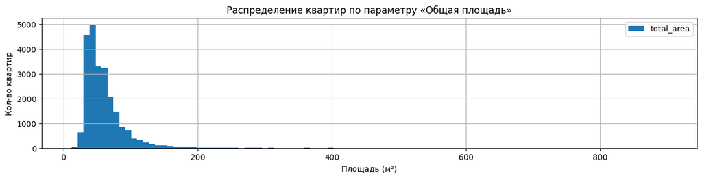

```python
describe_info(data.total_area)

plt.title('Распределение квартир по параметру «Общая площадь»')
plt.xlabel('Площадь (м²)')
plt.ylabel('Кол-во квартир');
```

Наблюдаем значительный разброс значений и ярко выраженную правостороннюю асимметрию с очень длинным хвостом.

Изучим более подробнее, рассмотрим аномалии на гистограмме.

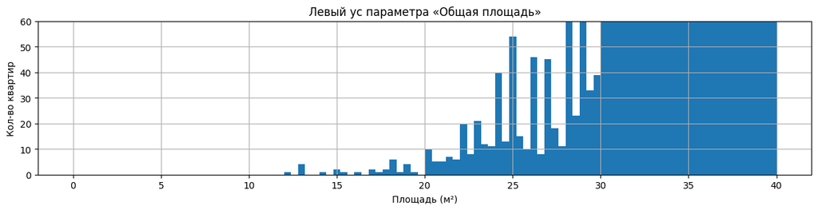

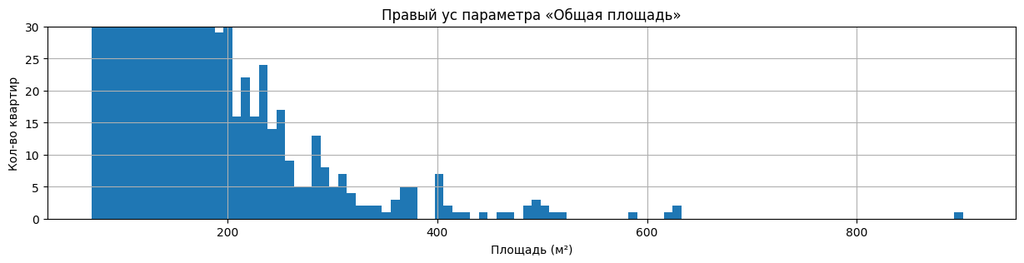

```python
data.hist(column = 'total_area', bins = 100, figsize = (15,3), range = (0,40), grid=True)

plt.title('Левый ус параметра «Общая площадь»')
plt.xlabel('Площадь (м²)')
plt.ylabel('Кол-во квартир')
plt.ylim(0, 60)

data.hist(column = 'total_area', bins = 100, figsize = (15,3), range = (70,910), grid=True)

plt.title('Правый ус параметра «Общая площадь»')
plt.xlabel('Площадь (м²)')
plt.ylabel('Кол-во квартир')
plt.ylim(0, 30);
```

Согласно общим данным и графику, квартиры площадью менее 20 и более 200 метров являются редкостью. Средняя площадь объектов недвижимости около 52 м². Удалим эти аномальные значения.

```python
data = data.drop(data[data['total_area'] < 20].index)
data = data.drop(data[data['total_area'] > 200].index)
```

Проверим очищенные данные.

```
Минимальное, максимальное и среднее значение:
```

```
count    23403.000000
mean        58.248853
std         26.524525
min         20.000000
25%         40.000000
50%         52.000000
75%         69.000000
max        200.000000
Name: total_area, dtype: float64
```

```
Медианное значение:
```

```
52.0
```

```
Общее количество строк:
```

```
23403
```

```
График:
```

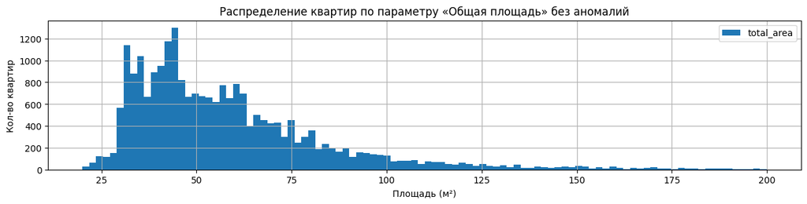

```python
describe_info(data.total_area)

plt.title('Распределение квартир по параметру «Общая площадь» без аномалий')
plt.xlabel('Площадь (м²)')
plt.ylabel('Кол-во квартир');
```

**Вывод по параметру:**

Удалено около 1,07% от исходных данных.

Теперь показатели общей площади составляют: минимальная — 20 м², максимальная — 200 м², средняя — 52 м². Хвост все еще большой, изучим показатели в конце этапа обработки аномалий.

### 3.1.2. Параметр «Жилая площадь»

```
Минимальное, максимальное и среднее значение:
```

```
count    21538.000000
mean        33.277894
std         17.373319
min          2.000000
25%         18.600000
50%         30.000000
75%         42.000000
max        164.700000
Name: living_area, dtype: float64
```

```
Медианное значение:
```

```
30.0
```

```
Общее количество строк:
```

```
23403
```

```
График:
```

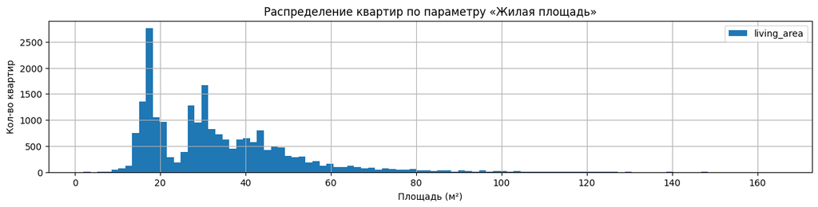

```python
describe_info(data.living_area)

plt.title('Распределение квартир по параметру «Жилая площадь»')
plt.xlabel('Площадь (м²)')
plt.ylabel('Кол-во квартир');
```

Наблюдаем такую же ситуацию, как и с общей площадью: очень большой разброс, при этом медиана находится на уровне 30 метров, а среднее арифметическое — 33 метра.

На графике видны два пика: первый — от 15 до 20 метров, второй — от 25 до 35 метров, и есть длинный «хвост». Рассмотрим подробнее левый и правый край графика.

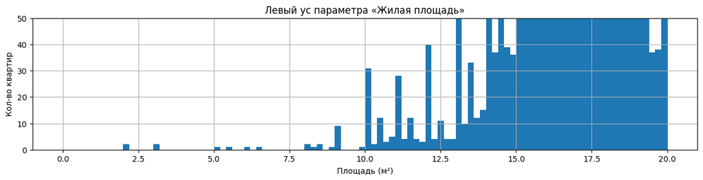

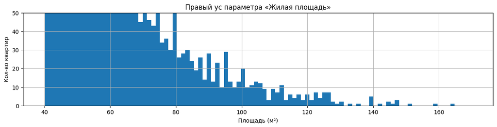

```python
data.hist(column = 'living_area', bins = 100, figsize = (15,3), range = (0,20), grid=True)
plt.title('Левый ус параметра «Жилая площадь»')
plt.xlabel('Площадь (м²)')
plt.ylabel('Кол-во квартир')
plt.ylim(0, 50)

data.hist(column = 'living_area', bins = 100, figsize = (15,3), range = (40,170), grid=True)
plt.title('Правый ус параметра «Жилая площадь»')
plt.xlabel('Площадь (м²)')
plt.ylabel('Кол-во квартир')
plt.ylim(0, 50);
```

Аномальные значения находятся в диапазонах до 7 и от 130 метров. Однако объектов площадью от 100 до 120 не так много. Исключим эти значения из наших данных.

```python
data = data.drop(data[data['living_area'] <= 7].index)
data = data.drop(data[data['living_area'] >= 100].index)
```

Проверим очищенные данные.

```
Минимальное, максимальное и среднее значение:
```

```
count    21348.000000
mean        32.597433
std         15.691389
min          8.000000
25%         18.500000
50%         30.000000
75%         42.000000
max         99.900000
Name: living_area, dtype: float64
```

```
Медианное значение:
```

```
30.0
```

```
Общее количество строк:
```

```
23213
```

```
График:
```

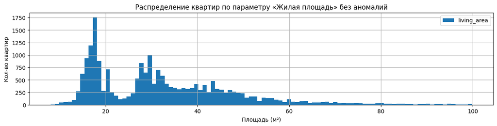

```python
describe_info(data.living_area)

plt.title('Распределение квартир по параметру «Жилая площадь» без аномалий')
plt.xlabel('Площадь (м²)')
plt.ylabel('Кол-во квартир');
```

**Вывод по параметру:**

Удалено около 0,8% от исходных данных.

После удаления аномальных значений медиана не изменилась и составляет 30 м². Минимальная жилая площадь составляет 8 м², максимальная — 99,9 м².

### 3.1.3. Параметр «Площадь кухни»

```
Минимальное, максимальное и среднее значение:
```

```
count    20994.000000
mean        10.329214
std          5.305395
min          1.300000
25%          7.000000
50%          9.000000
75%         11.800000
max         93.200000
Name: kitchen_area, dtype: float64
```

```
Медианное значение:
```

```
9.0
```

```
Общее количество строк:
```

```
23213
```

```
График:
```

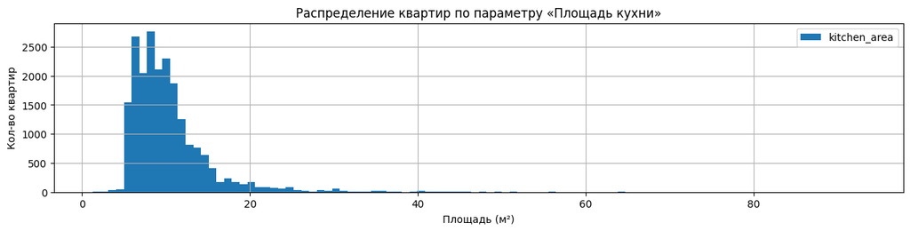

```python
describe_info(data.kitchen_area)

plt.title('Распределение квартир по параметру «Площадь кухни»')
plt.xlabel('Площадь (м²)')
plt.ylabel('Кол-во квартир');
```

Аналогично, наблюдаем аномальные значения, такие как кухня площадью в 1,30 и 93 метра. Это подтверждает график с очень большой и явной положительной ассиметрией.

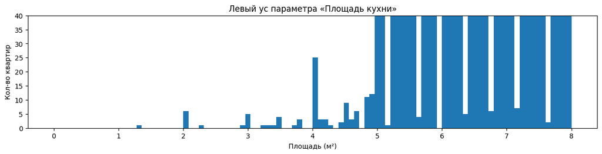

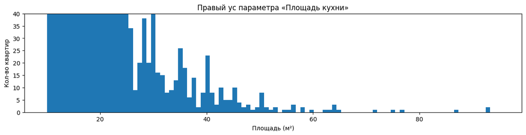

```python
data.hist(column = 'kitchen_area', bins = 100, figsize = (15,3), range = (0,8), grid=False)
plt.title('Левый ус параметра «Площадь кухни»')
plt.xlabel('Площадь (м²)')
plt.ylabel('Кол-во квартир')
plt.ylim(0, 40)

data.hist(column = 'kitchen_area', bins = 100, figsize = (15,3), range = (10,95), grid=False)
plt.title('Правый ус параметра «Площадь кухни»')
plt.xlabel('Площадь (м²)')
plt.ylabel('Кол-во квартир')
plt.ylim(0, 40);
```

На графиках видно, аномально низкое количество объектов площадью до 5 и от 40 метров. Удалим их.

```python
data = data.drop(data[data['kitchen_area'] < 5].index)
data = data.drop(data[data['kitchen_area'] > 40].index)
```

```
Минимальное, максимальное и среднее значение:
```

```
count    20803.000000
mean        10.186686
std          4.564955
min          5.000000
25%          7.000000
50%          9.000000
75%         11.780000
max         40.000000
Name: kitchen_area, dtype: float64
```

```
Медианное значение:
```

```
9.0
```

```
Общее количество строк:
```

```
23022
```

```
График:
```

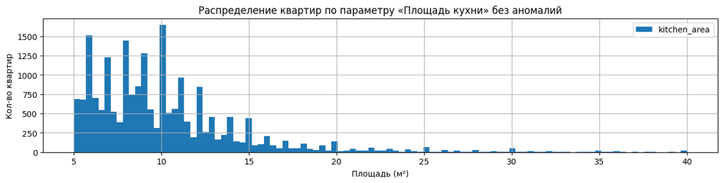

```python
describe_info(data.kitchen_area)

plt.title('Распределение квартир по параметру «Площадь кухни» без аномалий')
plt.xlabel('Площадь (м²)')
plt.ylabel('Кол-во квартир');
```

**Вывод по параметру:**

Удалено около 0,8% от исходных данных.

### 3.1.4. Параметр «Высота потолков»

```
Минимальное, максимальное и среднее значение:
```

```
count    14033.000000
mean         2.759877
std          1.277111
min          1.000000
25%          2.500000
50%          2.650000
75%          2.800000
max        100.000000
Name: ceiling_height, dtype: float64
```

```
Медианное значение:
```

```
2.65
```

```
Общее количество строк:
```

```
23022
```

```
График:
```

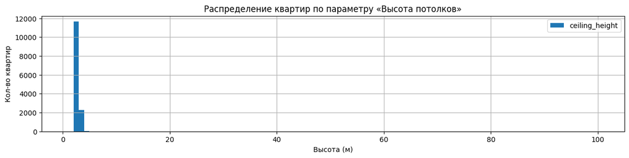

```python
describe_info(data.ceiling_height)

plt.title('Распределение квартир по параметру «Высота потолков»')
plt.xlabel('Высота (м)')
plt.ylabel('Кол-во квартир');
```

Разница в данных впечатляет, значения высоты потолков в 1 метр и 100 метров кажутся невероятными. Рассмотрим эти квартиры более подробно.

```python
data.query('ceiling_height < 2.5')
```

|  | total_images | last_price | total_area | first_day_exposition | rooms | ceiling_height | floors_total | living_area | floor | is_apartment | ... | parks_nearest | ponds_around3000 | ponds_nearest | days_exposition | price_area | public_week_day | public_month | public_year | city_centers_nearest_km | type_floor |
| --- | --- | --- | --- | --- | --- | --- | --- | --- | --- | --- | --- | --- | --- | --- | --- | --- | --- | --- | --- | --- | --- |
| 193 | 6 | 7920000 | 83.8 | 2017-08-17 | 4 | 2.47 | 9 | 55.9 | 9 | False | ... | NaN | 1 | 289.0 | 155 | 94510.74 | 3 | 8 | 2017 | 8.0 | последний |
| 227 | 13 | 2200000 | 47.0 | 2018-01-12 | 3 | 2.34 | 5 | NaN | 1 | False | ... | NaN | 0 | NaN | 45 | 46808.51 | 4 | 1 | 2018 | NaN | первый |
| 552 | 11 | 2999000 | 33.5 | 2017-03-30 | 1 | 2.00 | 15 | 17.5 | 6 | False | ... | 520.0 | 1 | 949.0 | 270 | 89522.39 | 3 | 3 | 2017 | 12.0 | другой |
| 632 | 20 | 3350000 | 35.0 | 2017-11-14 | 2 | 2.45 | 9 | 21.0 | 9 | False | ... | NaN | 0 | NaN | 0 | 95714.29 | 1 | 11 | 2017 | NaN | последний |
| 987 | 12 | 7100000 | 65.5 | 2016-03-30 | 4 | 2.46 | 5 | 51.0 | 4 | False | ... | 572.0 | 0 | NaN | 82 | 108396.95 | 2 | 3 | 2016 | 5.0 | другой |
| ... | ... | ... | ... | ... | ... | ... | ... | ... | ... | ... | ... | ... | ... | ... | ... | ... | ... | ... | ... | ... | ... |
| 22584 | 12 | 1700000 | 42.0 | 2018-10-22 | 2 | 2.47 | 2 | NaN | 2 | False | ... | NaN | 0 | NaN | 0 | 40476.19 | 0 | 10 | 2018 | NaN | последний |
| 22590 | 16 | 6000000 | 55.0 | 2018-10-31 | 2 | 1.00 | 12 | 32.4 | 7 | False | ... | 293.0 | 2 | 289.0 | 13 | 109090.91 | 2 | 10 | 2018 | 14.0 | другой |
| 22960 | 17 | 2300000 | 53.6 | 2018-10-18 | 2 | 2.00 | 2 | 19.0 | 1 | False | ... | NaN | 0 | NaN | 0 | 42910.45 | 3 | 10 | 2018 | NaN | первый |
| 23121 | 20 | 4290000 | 35.2 | 2018-09-12 | 1 | 2.47 | 14 | 20.0 | 7 | False | ... | 506.0 | 0 | NaN | 41 | 121875.00 | 2 | 9 | 2018 | 13.0 | другой |
| 23496 | 7 | 3300000 | 55.3 | 2018-06-19 | 2 | 2.45 | 14 | 31.0 | 2 | False | ... | NaN | 0 | NaN | 62 | 59674.50 | 1 | 6 | 2018 | NaN | другой |

71 rows × 28 columns

```python
data.query('ceiling_height > 5')
```

|  | total_images | last_price | total_area | first_day_exposition | rooms | ceiling_height | floors_total | living_area | floor | is_apartment | ... | parks_nearest | ponds_around3000 | ponds_nearest | days_exposition | price_area | public_week_day | public_month | public_year | city_centers_nearest_km | type_floor |
| --- | --- | --- | --- | --- | --- | --- | --- | --- | --- | --- | --- | --- | --- | --- | --- | --- | --- | --- | --- | --- | --- |
| 355 | 17 | 3600000 | 55.2 | 2018-07-12 | 2 | 25.0 | 5 | 32.0 | 2 | False | ... | NaN | 0 | NaN | 259 | 65217.39 | 3 | 7 | 2018 | NaN | другой |
| 3148 | 14 | 2900000 | 75.0 | 2018-11-12 | 3 | 32.0 | 3 | 53.0 | 2 | False | ... | NaN | 0 | NaN | 0 | 38666.67 | 0 | 11 | 2018 | NaN | другой |
| 3474 | 3 | 1400000 | 30.0 | 2018-03-16 | 1 | 8.0 | 5 | 15.3 | 2 | False | ... | NaN | 0 | NaN | 125 | 46666.67 | 4 | 3 | 2018 | NaN | другой |
| 4643 | 0 | 4300000 | 45.0 | 2018-02-01 | 2 | 25.0 | 9 | 30.0 | 2 | False | ... | 658.0 | 1 | 331.0 | 181 | 95555.56 | 3 | 2 | 2018 | 13.0 | другой |
| 4876 | 7 | 3000000 | 25.0 | 2017-09-27 | 0 | 27.0 | 25 | 17.0 | 17 | False | ... | NaN | 0 | NaN | 28 | 120000.00 | 2 | 9 | 2017 | NaN | другой |
| 5076 | 0 | 3850000 | 30.5 | 2018-10-03 | 1 | 24.0 | 5 | 19.5 | 1 | True | ... | 397.0 | 1 | 578.0 | 7 | 126229.51 | 2 | 10 | 2018 | 8.0 | первый |
| 5246 | 0 | 2500000 | 54.0 | 2017-10-13 | 2 | 27.0 | 5 | 30.0 | 3 | False | ... | NaN | 0 | NaN | 540 | 46296.30 | 4 | 10 | 2017 | NaN | другой |
| 5669 | 4 | 4400000 | 50.0 | 2017-08-08 | 2 | 26.0 | 9 | 21.3 | 3 | False | ... | 305.0 | 0 | NaN | 267 | 88000.00 | 1 | 8 | 2017 | 11.0 | другой |
| 5807 | 17 | 8150000 | 80.0 | 2019-01-09 | 2 | 27.0 | 36 | 41.0 | 13 | False | ... | NaN | 3 | 80.0 | 38 | 101875.00 | 2 | 1 | 2019 | 20.0 | другой |
| 5863 | 20 | 5650000 | 45.0 | 2018-08-15 | 1 | 8.3 | 16 | 19.3 | 14 | False | ... | NaN | 1 | 613.0 | 14 | 125555.56 | 2 | 8 | 2018 | 11.0 | другой |
| 6246 | 6 | 3300000 | 44.4 | 2019-03-25 | 2 | 25.0 | 5 | 31.3 | 5 | False | ... | 417.0 | 2 | 73.0 | 0 | 74324.32 | 0 | 3 | 2019 | 51.0 | последний |
| 7578 | 17 | 38000000 | 143.0 | 2017-11-02 | 3 | 5.5 | 5 | 83.0 | 5 | False | ... | 479.0 | 0 | NaN | 0 | 265734.27 | 3 | 11 | 2017 | 6.0 | последний |
| 9379 | 5 | 3950000 | 42.0 | 2017-03-26 | 3 | 25.0 | 5 | 30.0 | 2 | False | ... | NaN | 0 | NaN | 0 | 94047.62 | 6 | 3 | 2017 | 14.0 | другой |
| 10773 | 8 | 3800000 | 58.0 | 2017-10-13 | 2 | 27.0 | 10 | 30.1 | 3 | False | ... | NaN | 0 | NaN | 71 | 65517.24 | 4 | 10 | 2017 | NaN | другой |
| 11285 | 0 | 1950000 | 37.0 | 2019-03-20 | 1 | 25.0 | 5 | 17.0 | 4 | False | ... | NaN | 0 | NaN | 18 | 52702.70 | 2 | 3 | 2019 | NaN | другой |
| 12628 | 14 | 3900000 | 50.0 | 2018-03-29 | 1 | 5.3 | 5 | NaN | 5 | False | ... | 505.0 | 1 | 92.0 | 8 | 78000.00 | 3 | 3 | 2018 | 4.0 | последний |
| 14382 | 9 | 1700000 | 35.0 | 2015-12-04 | 1 | 25.0 | 5 | 20.0 | 2 | False | ... | NaN | 0 | NaN | 206 | 48571.43 | 4 | 12 | 2015 | NaN | другой |
| 15061 | 19 | 5600000 | 56.4 | 2018-05-11 | 2 | 14.0 | 14 | 32.4 | 5 | False | ... | NaN | 0 | NaN | 315 | 99290.78 | 4 | 5 | 2018 | 14.0 | другой |
| 15743 | 14 | 5600000 | 67.0 | 2016-11-11 | 3 | 8.0 | 16 | 41.0 | 1 | False | ... | 723.0 | 0 | NaN | 474 | 83582.09 | 4 | 11 | 2016 | 11.0 | первый |
| 17442 | 0 | 5350000 | 54.0 | 2015-06-16 | 2 | 8.0 | 5 | 29.0 | 2 | False | ... | NaN | 0 | NaN | 469 | 99074.07 | 1 | 6 | 2015 | 28.0 | другой |
| 17496 | 15 | 6700000 | 92.9 | 2019-02-19 | 3 | 20.0 | 17 | 53.2 | 14 | False | ... | 967.0 | 0 | NaN | 0 | 72120.56 | 1 | 2 | 2019 | 15.0 | другой |
| 17857 | 1 | 3900000 | 56.0 | 2017-12-22 | 3 | 27.0 | 5 | 33.0 | 4 | False | ... | NaN | 0 | NaN | 73 | 69642.86 | 4 | 12 | 2017 | 16.0 | другой |
| 18545 | 6 | 3750000 | 43.0 | 2019-03-18 | 2 | 25.0 | 5 | 29.0 | 3 | False | ... | 540.0 | 0 | NaN | 12 | 87209.30 | 0 | 3 | 2019 | 8.0 | другой |
| 20478 | 11 | 8000000 | 45.0 | 2017-07-18 | 1 | 27.0 | 4 | 22.0 | 2 | False | ... | NaN | 3 | 449.0 | 429 | 177777.78 | 1 | 7 | 2017 | 3.0 | другой |
| 20507 | 12 | 5950000 | 60.0 | 2018-02-19 | 2 | 22.6 | 14 | 35.0 | 11 | False | ... | NaN | 0 | NaN | 40 | 99166.67 | 0 | 2 | 2018 | 13.0 | другой |
| 21227 | 0 | 8200000 | 71.0 | 2017-07-21 | 0 | 5.8 | 5 | 68.0 | 5 | False | ... | 295.0 | 3 | 366.0 | 30 | 115492.96 | 4 | 7 | 2017 | 1.0 | последний |
| 21377 | 19 | 4900000 | 42.0 | 2017-04-18 | 1 | 27.5 | 24 | 37.7 | 19 | False | ... | NaN | 0 | NaN | 61 | 116666.67 | 1 | 4 | 2017 | 10.0 | другой |
| 21824 | 20 | 2450000 | 44.0 | 2019-02-12 | 2 | 27.0 | 2 | 38.0 | 2 | False | ... | NaN | 0 | NaN | 0 | 55681.82 | 1 | 2 | 2019 | NaN | последний |
| 22309 | 20 | 5300000 | 45.0 | 2017-09-30 | 1 | 10.3 | 16 | 15.5 | 15 | False | ... | 440.0 | 2 | 450.0 | 136 | 117777.78 | 5 | 9 | 2017 | 12.0 | другой |
| 22336 | 19 | 9999000 | 92.4 | 2019-04-05 | 2 | 32.0 | 6 | 55.5 | 5 | False | ... | NaN | 3 | 511.0 | 0 | 108214.29 | 4 | 4 | 2019 | 4.0 | другой |
| 22869 | 0 | 15000000 | 25.0 | 2018-07-25 | 1 | 100.0 | 5 | 14.0 | 5 | True | ... | 223.0 | 3 | 30.0 | 19 | 600000.00 | 2 | 7 | 2018 | 8.0 | последний |
| 22938 | 14 | 4000000 | 98.0 | 2018-03-15 | 4 | 27.0 | 2 | 73.0 | 2 | True | ... | NaN | 0 | NaN | 27 | 40816.33 | 3 | 3 | 2018 | NaN | последний |

32 rows × 28 columns

Вероятно, эти необычные потолки высотой в 25 или 27 метров на самом деле имеют высоту 2,5 и 2,7 метра. Мы можем скорректировать значения, но их не так много, поэтому лучше исключим эти объекты из анализа.

```python
data = data.drop(data[data['ceiling_height'] < 2.5].index)
data = data.drop(data[data['ceiling_height'] > 4].index)
```

```
Минимальное, максимальное и среднее значение:
```

```
count    13901.000000
mean         2.711449
std          0.242931
min          2.500000
25%          2.510000
50%          2.650000
75%          2.800000
max          4.000000
Name: ceiling_height, dtype: float64
```

```
Медианное значение:
```

```
2.65
```

```
Общее количество строк:
```

```
22890
```

```
График:
```

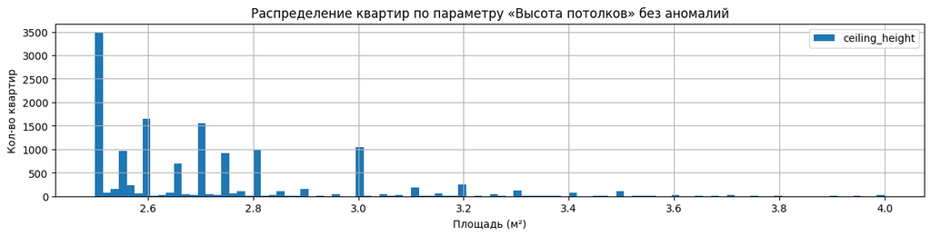

```python
describe_info(data.ceiling_height)

plt.title('Распределение квартир по параметру «Высота потолков» без аномалий')
plt.xlabel('Площадь (м²)')
plt.ylabel('Кол-во квартир');
```

**Вывод по параметру:**

Удалено около 0.56% от исходных данных.

Теперь минимальная высота — 2.5 метра, максимальная — 4 метра. Медиана находится на уровне 2.65 метра.

### 3.1.5. Параметр «Количество комнат»

```
Минимальное, максимальное и среднее значение:
```

```
count    22890.000000
mean         2.011315
std          0.957393
min          0.000000
25%          1.000000
50%          2.000000
75%          3.000000
max          7.000000
Name: rooms, dtype: float64
```

```
Медианное значение:
```

```
2.0
```

```
Общее количество строк:
```

```
22890
```

```
График:
```

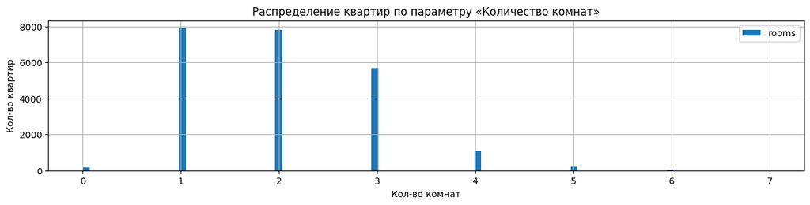

```python
describe_info(data.rooms)

plt.title('Распределение квартир по параметру «Количество комнат»')
plt.xlabel('Кол-во комнат')
plt.ylabel('Кол-во квартир');
```

В целом, распределение выглядит нормально, но есть вопросы по квартирам с 0 комнатами, возможно, это студии или квартиры со свободной планировкой. Также мы рассмотрим квартиры с более чем 5 комнатами.

```python
data.query('rooms == 0')
```

|  | total_images | last_price | total_area | first_day_exposition | rooms | ceiling_height | floors_total | living_area | floor | is_apartment | ... | parks_nearest | ponds_around3000 | ponds_nearest | days_exposition | price_area | public_week_day | public_month | public_year | city_centers_nearest_km | type_floor |
| --- | --- | --- | --- | --- | --- | --- | --- | --- | --- | --- | --- | --- | --- | --- | --- | --- | --- | --- | --- | --- | --- |
| 144 | 1 | 2450000 | 27.00 | 2017-03-30 | 0 | NaN | 24 | 15.50 | 2 | False | ... | NaN | 0 | NaN | 181 | 90740.74 | 3 | 3 | 2017 | NaN | другой |
| 349 | 4 | 2320000 | 25.00 | 2017-09-27 | 0 | NaN | 14 | 17.00 | 1 | False | ... | NaN | 0 | NaN | 45 | 92800.00 | 2 | 9 | 2017 | NaN | первый |
| 440 | 8 | 2480000 | 27.11 | 2018-03-12 | 0 | NaN | 17 | 24.75 | 4 | False | ... | NaN | 2 | 982.0 | 64 | 91479.16 | 0 | 3 | 2018 | 15.0 | другой |
| 508 | 0 | 3375000 | 34.40 | 2017-03-28 | 0 | NaN | 26 | 24.30 | 19 | False | ... | NaN | 1 | 593.0 | 430 | 98110.47 | 1 | 3 | 2017 | 19.0 | другой |
| 608 | 2 | 1850000 | 25.00 | 2019-02-20 | 0 | NaN | 10 | NaN | 7 | False | ... | NaN | 0 | NaN | 29 | 74000.00 | 2 | 2 | 2019 | NaN | другой |
| ... | ... | ... | ... | ... | ... | ... | ... | ... | ... | ... | ... | ... | ... | ... | ... | ... | ... | ... | ... | ... | ... |
| 23210 | 7 | 3200000 | 26.00 | 2017-09-01 | 0 | NaN | 25 | 18.00 | 16 | False | ... | NaN | 1 | 623.0 | 14 | 123076.92 | 4 | 9 | 2017 | 13.0 | другой |
| 23442 | 0 | 2500000 | 27.70 | 2017-09-28 | 0 | NaN | 24 | 18.00 | 4 | False | ... | NaN | 0 | NaN | 4 | 90252.71 | 3 | 9 | 2017 | NaN | другой |
| 23554 | 15 | 3350000 | 26.00 | 2018-09-07 | 0 | NaN | 19 | NaN | 8 | False | ... | NaN | 2 | 112.0 | 31 | 128846.15 | 4 | 9 | 2018 | 17.0 | другой |
| 23592 | 10 | 1450000 | 29.00 | 2017-11-11 | 0 | NaN | 9 | 18.00 | 8 | False | ... | NaN | 0 | NaN | 82 | 50000.00 | 5 | 11 | 2017 | NaN | другой |
| 23637 | 8 | 2350000 | 26.00 | 2018-06-26 | 0 | NaN | 25 | 17.00 | 4 | False | ... | NaN | 0 | NaN | 207 | 90384.62 | 1 | 6 | 2018 | NaN | другой |

184 rows × 28 columns

Всего в данных 184 квартиры, в которых нет комнат. Посмотрим, сколько из этих квартир студий и квартир со свободной планировкой.

```python
print('Квартир студий:', data.query('rooms == 0 & studio == True').shape[0])
print('Квартир со свободной планировкой:', data.query('rooms == 0 & open_plan == True').shape[0])
```

```
Квартир студий: 128
Квартир со свободной планировкой: 56
```

Ошибок нет. Все квартиры без комнат — это студии или квартиры со свободной планировкой.

Рассмотрим характеристики квартир с наибольшим количеством комнат.

```python
data.query('rooms >= 6')
```

|  | total_images | last_price | total_area | first_day_exposition | rooms | ceiling_height | floors_total | living_area | floor | is_apartment | ... | parks_nearest | ponds_around3000 | ponds_nearest | days_exposition | price_area | public_week_day | public_month | public_year | city_centers_nearest_km | type_floor |
| --- | --- | --- | --- | --- | --- | --- | --- | --- | --- | --- | --- | --- | --- | --- | --- | --- | --- | --- | --- | --- | --- |
| 52 | 20 | 11795000 | 136.0 | 2017-09-22 | 6 | 3.00 | 2 | 94.0 | 2 | False | ... | 526.0 | 0 | NaN | 0 | 86727.94 | 4 | 9 | 2017 | 7.0 | последний |
| 201 | 5 | 10880000 | 123.1 | 2015-11-12 | 6 | 3.20 | 5 | 89.0 | 2 | False | ... | 516.0 | 0 | NaN | 992 | 88383.43 | 3 | 11 | 2015 | 3.0 | другой |
| 855 | 18 | 15000000 | 134.0 | 2017-10-27 | 7 | NaN | 4 | 88.0 | 3 | False | ... | 803.0 | 1 | 387.0 | 150 | 111940.30 | 4 | 10 | 2017 | 4.0 | другой |
| 2017 | 1 | 9100000 | 111.0 | 2017-07-04 | 6 | 2.75 | 3 | 84.5 | 3 | False | ... | 588.0 | 1 | 54.0 | 61 | 81981.98 | 1 | 7 | 2017 | 2.0 | последний |
| 2709 | 14 | 21500000 | 197.0 | 2018-07-04 | 6 | 3.00 | 6 | NaN | 2 | False | ... | 566.0 | 0 | NaN | 0 | 109137.06 | 2 | 7 | 2018 | 4.0 | другой |
| 3314 | 20 | 16550000 | 96.0 | 2018-02-16 | 6 | 2.60 | 5 | 80.0 | 3 | False | ... | 546.0 | 3 | 183.0 | 108 | 172395.83 | 4 | 2 | 2018 | 1.0 | другой |
| 3324 | 1 | 9200000 | 138.0 | 2016-03-22 | 6 | NaN | 5 | 77.6 | 2 | False | ... | 311.0 | 0 | NaN | 672 | 66666.67 | 1 | 3 | 2016 | 5.0 | другой |
| 5255 | 15 | 6100000 | 87.0 | 2017-06-28 | 6 | 3.50 | 3 | 68.0 | 2 | False | ... | 534.0 | 3 | 676.0 | 0 | 70114.94 | 2 | 6 | 2017 | 34.0 | другой |
| 6813 | 16 | 79000000 | 163.0 | 2019-02-26 | 6 | 3.20 | 5 | 90.0 | 5 | False | ... | 230.0 | 1 | 134.0 | 46 | 484662.58 | 1 | 2 | 2019 | 2.0 | последний |
| 9856 | 13 | 12000000 | 106.0 | 2018-07-30 | 6 | 2.80 | 3 | 70.0 | 1 | False | ... | NaN | 1 | 238.0 | 0 | 113207.55 | 0 | 7 | 2018 | 5.0 | первый |
| 10177 | 9 | 13030000 | 130.3 | 2017-10-20 | 6 | NaN | 5 | 93.0 | 2 | False | ... | 429.0 | 0 | NaN | 0 | 100000.00 | 4 | 10 | 2017 | 7.0 | другой |
| 10200 | 17 | 14500000 | 188.1 | 2018-08-08 | 6 | NaN | 3 | 80.0 | 3 | False | ... | 541.0 | 3 | 348.0 | 96 | 77086.66 | 2 | 8 | 2018 | 34.0 | последний |
| 10763 | 4 | 13000000 | 154.1 | 2018-02-06 | 6 | NaN | 5 | NaN | 2 | False | ... | 461.0 | 2 | 641.0 | 90 | 84360.80 | 1 | 2 | 2018 | 2.0 | другой |
| 11409 | 20 | 9990000 | 120.0 | 2016-03-15 | 6 | NaN | 16 | 96.0 | 3 | False | ... | NaN | 0 | NaN | 323 | 83250.00 | 1 | 3 | 2016 | 14.0 | другой |
| 12487 | 20 | 11970000 | 120.6 | 2015-01-21 | 6 | 3.46 | 6 | 82.3 | 3 | False | ... | 221.0 | 1 | 794.0 | 1350 | 99253.73 | 2 | 1 | 2015 | 4.0 | другой |
| 12811 | 9 | 20000000 | 128.0 | 2019-04-04 | 6 | 3.56 | 5 | 85.3 | 3 | False | ... | 526.0 | 1 | 935.0 | 0 | 156250.00 | 3 | 4 | 2019 | 5.0 | другой |
| 13082 | 4 | 23000000 | 150.0 | 2019-02-11 | 6 | 3.00 | 5 | 99.0 | 2 | False | ... | NaN | 0 | NaN | 0 | 153333.33 | 0 | 2 | 2019 | 4.0 | другой |
| 14264 | 13 | 14000000 | 94.0 | 2019-01-23 | 6 | 2.65 | 0 | 51.0 | 23 | False | ... | NaN | 0 | NaN | 0 | 148936.17 | 2 | 1 | 2019 | 13.0 | None |
| 14510 | 3 | 6864000 | 95.0 | 2018-10-12 | 6 | 2.50 | 15 | 75.0 | 3 | False | ... | NaN | 2 | 575.0 | 12 | 72252.63 | 4 | 10 | 2018 | 11.0 | другой |
| 14603 | 12 | 13490000 | 100.6 | 2018-07-31 | 7 | NaN | 4 | NaN | 2 | True | ... | 574.0 | 3 | 325.0 | 50 | 134095.43 | 1 | 7 | 2018 | 4.0 | другой |
| 14649 | 11 | 12990000 | 106.0 | 2018-07-08 | 6 | NaN | 4 | NaN | 1 | False | ... | NaN | 1 | 361.0 | 90 | 122547.17 | 6 | 7 | 2018 | 4.0 | первый |
| 15196 | 20 | 24000000 | 135.0 | 2019-05-01 | 7 | 3.00 | 5 | 75.1 | 1 | False | ... | NaN | 1 | 667.0 | 0 | 177777.78 | 2 | 5 | 2019 | 5.0 | первый |
| 15340 | 19 | 36750000 | 160.2 | 2017-11-08 | 6 | NaN | 5 | 90.0 | 3 | False | ... | 349.0 | 1 | 484.0 | 68 | 229400.75 | 2 | 11 | 2017 | 4.0 | другой |
| 17534 | 6 | 21000000 | 154.0 | 2018-12-18 | 6 | 3.51 | 5 | 99.1 | 1 | False | ... | 328.0 | 3 | 132.0 | 116 | 136363.64 | 1 | 12 | 2018 | 2.0 | первый |
| 17991 | 19 | 12000000 | 125.0 | 2017-02-09 | 7 | 3.30 | 6 | 82.0 | 5 | False | ... | 407.0 | 0 | NaN | 138 | 96000.00 | 3 | 2 | 2017 | 5.0 | другой |
| 18548 | 19 | 11700000 | 119.0 | 2018-08-27 | 6 | 3.00 | 10 | 86.2 | 3 | False | ... | 86.0 | 1 | 590.0 | 204 | 98319.33 | 0 | 8 | 2018 | 10.0 | другой |
| 20260 | 13 | 9500000 | 135.0 | 2018-08-19 | 6 | 2.70 | 12 | 90.0 | 1 | False | ... | NaN | 2 | 430.0 | 0 | 70370.37 | 6 | 8 | 2018 | 17.0 | первый |
| 21218 | 0 | 9000000 | 125.7 | 2018-03-21 | 6 | 2.55 | 15 | 73.6 | 15 | False | ... | NaN | 0 | NaN | 60 | 71599.05 | 2 | 3 | 2018 | 13.0 | последний |
| 22122 | 7 | 8500000 | 128.3 | 2016-06-28 | 6 | NaN | 9 | 81.9 | 2 | False | ... | NaN | 0 | NaN | 553 | 66250.97 | 1 | 6 | 2016 | NaN | другой |
| 22264 | 20 | 22000000 | 141.0 | 2019-01-24 | 7 | NaN | 5 | 84.0 | 2 | False | ... | 447.0 | 1 | 468.0 | 90 | 156028.37 | 3 | 1 | 2019 | 3.0 | другой |
| 22317 | 1 | 17508600 | 184.3 | 2018-10-02 | 6 | 2.75 | 18 | NaN | 16 | False | ... | 497.0 | 0 | NaN | 56 | 95000.54 | 1 | 10 | 2018 | 10.0 | другой |
| 23047 | 11 | 10500000 | 110.0 | 2018-06-30 | 6 | 3.20 | 7 | 75.0 | 6 | False | ... | NaN | 0 | NaN | 0 | 95454.55 | 5 | 6 | 2018 | 4.0 | другой |
| 23555 | 5 | 15350000 | 158.5 | 2019-03-07 | 7 | 2.95 | 7 | 57.4 | 7 | False | ... | 347.0 | 0 | NaN | 0 | 96845.43 | 3 | 3 | 2019 | 3.0 | последний |

33 rows × 28 columns

**Вывод по параметру:**

С этими данными все в порядке, ничего удалять не нужно.

### 3.1.6. Параметр «Количество этажей в доме»

```
Минимальное, максимальное и среднее значение:
```

```
count    22890.000000
mean        10.754915
std          6.633615
min          0.000000
25%          5.000000
50%          9.000000
75%         16.000000
max         60.000000
Name: floors_total, dtype: float64
```

```
Медианное значение:
```

```
9.0
```

```
Общее количество строк:
```

```
22890
```

```
График:
```

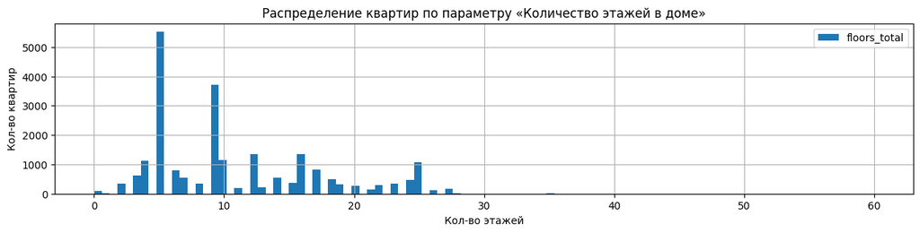

```python
describe_info(data.floors_total)

plt.title('Распределение квартир по параметру «Количество этажей в доме»')
plt.xlabel('Кол-во этажей')
plt.ylabel('Кол-во квартир');
```

Наблюдаем аномальное значение в 60 этажей. Также рассмотрим значения в 0 этажей, которые, вероятно, соответствуют частным домам.

```python
data.query('floors_total > 35')
```

|  | total_images | last_price | total_area | first_day_exposition | rooms | ceiling_height | floors_total | living_area | floor | is_apartment | ... | parks_nearest | ponds_around3000 | ponds_nearest | days_exposition | price_area | public_week_day | public_month | public_year | city_centers_nearest_km | type_floor |
| --- | --- | --- | --- | --- | --- | --- | --- | --- | --- | --- | --- | --- | --- | --- | --- | --- | --- | --- | --- | --- | --- |
| 397 | 15 | 5990000 | 54.0 | 2018-03-22 | 2 | NaN | 36 | 21.4 | 28 | False | ... | NaN | 3 | 80.0 | 11 | 110925.93 | 3 | 3 | 2018 | 20.0 | другой |
| 2253 | 12 | 3800000 | 45.5 | 2018-06-28 | 2 | 2.88 | 60 | 27.4 | 4 | False | ... | 342.0 | 3 | 614.0 | 166 | 83516.48 | 3 | 6 | 2018 | 49.0 | другой |
| 11079 | 16 | 9200000 | 75.0 | 2019-02-22 | 2 | 2.70 | 36 | 40.0 | 29 | False | ... | NaN | 3 | 80.0 | 0 | 122666.67 | 4 | 2 | 2019 | 20.0 | другой |
| 16731 | 9 | 3978000 | 40.0 | 2018-09-24 | 1 | 2.65 | 52 | 10.5 | 18 | False | ... | 793.0 | 0 | NaN | 45 | 99450.00 | 0 | 9 | 2018 | 13.0 | другой |

4 rows × 28 columns

Изучим квартиры с 0 и 1 этажами в доме и рассмотрим города, в которых они находятся.

```python
data.query('floors_total == 1')['locality_name'].value_counts()
```

```
городской поселок Рощино              2
Сестрорецк                            2
Луга                                  2
Санкт-Петербург                       2
деревня Сижно                         1
городской поселок Будогощь            1
поселок Пчевжа                        1
деревня Большие Колпаны               1
поселок Суйда                         1
деревня Каськово                      1
поселок городского типа Ефимовский    1
поселок Оредеж                        1
городской поселок Большая Ижора       1
поселок Сосново                       1
Зеленогорск                           1
Волосово                              1
поселок Гаврилово                     1
Name: locality_name, dtype: int64
```

```python
data.query('floors_total == 0')['locality_name'].value_counts()
```

```
Санкт-Петербург                    69
поселок Мурино                      4
Красное Село                        2
Кудрово                             2
поселок Стрельна                    1
городской поселок Новоселье         1
поселок Бугры                       1
деревня Новое Девяткино             1
поселок Щеглово                     1
поселок городского типа Токсово     1
Name: locality_name, dtype: int64
```

Квартир в домах выше 35 этажей очень мало. И, насколько известно, самый высокий дом в Санкт-Петербурге и области — 35-этажный. Поэтому удалим все объекты выше 35 этажей.

Ситуация с квартирами в одноэтажных домах неоднозначна. Одноэтажные дома расположены в области или небольших городах, где это могут быть старые или частные дома, и в целом всё в порядке.

Однако есть вопросы по поводу домов без этажей, большинство из которых находится в Санкт-Петербурге. В их данных указаны разные этажи. Поэтому мы исключим эти квартиры из нашего исследования.

```python
data = data.drop(data[data['floors_total'] > 35].index)
data = data.drop(data[data['floors_total'] == 0].index)
```

```
Минимальное, максимальное и среднее значение:
```

```
count    22802.000000
mean        10.788352
std          6.596255
min          1.000000
25%          5.000000
50%          9.000000
75%         16.000000
max         35.000000
Name: floors_total, dtype: float64
```

```
Медианное значение:
```

```
9.0
```

```
Общее количество строк:
```

```
22802
```

```
График:
```

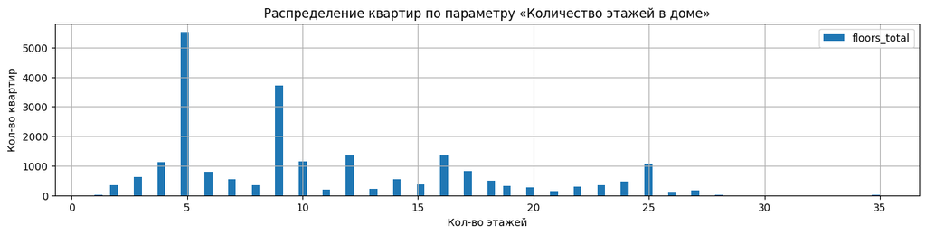

```python
describe_info(data.floors_total)

plt.title('Распределение квартир по параметру «Количество этажей в доме»')
plt.xlabel('Кол-во этажей')
plt.ylabel('Кол-во квартир');
```

**Вывод по параметру:**

Удалено около 0,37% от исходных данных.

В среднем дома имеют 9 этажей. Минимальная высота дома — 1 этаж, максимальная — 35 этажей.

### 3.1.7. Параметр «Тип этажа квартиры»

```python
data.type_floor.value_counts().reset_index()
```

|  | index | type_floor |
| --- | --- | --- |
| 0 | другой | 16849 |
| 1 | последний | 3137 |
| 2 | первый | 2816 |

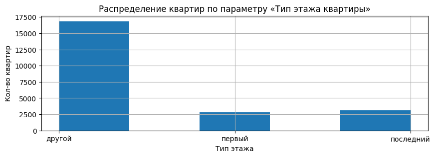

```python
data.type_floor.hist(bins=5, figsize=(10, 3))

plt.title('Распределение квартир по параметру «Тип этажа квартиры»')
plt.xlabel('Тип этажа')
plt.ylabel('Кол-во квартир');
```

**Вывод по параметру:**

С данными все впорядке.

### 3.1.8. Параметр «Цена объекта»

Цены указаны в неудобном для восприятия формате. Изменим их и округлим до тысяч.

```python
data['last_price'] = data['last_price'] / 1000
```

```
Минимальное, максимальное и среднее значение:
```

```
count     22802.000000
mean       5831.922308
std        5655.869872
min         430.000000
25%        3400.000000
50%        4600.000000
75%        6596.000000
max      330000.000000
Name: last_price, dtype: float64
```

```
Медианное значение:
```

```
4600.0
```

```
Общее количество строк:
```

```
22802
```

```
График:
```

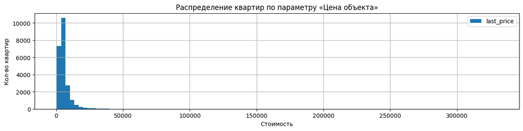

```python
describe_info(data.last_price)

plt.title('Распределение квартир по параметру «Цена объекта»')
plt.xlabel('Стоимость')
plt.ylabel('Кол-во квартир');
```

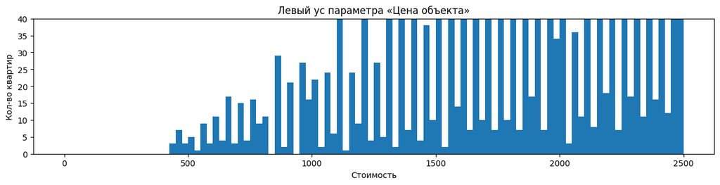

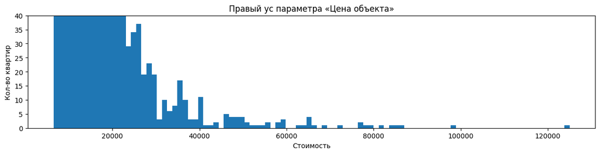

```python
data.hist(column = 'last_price', bins = 100, figsize = (15,3), range = (0,2500), grid=False)
plt.title('Левый ус параметра «Цена объекта»')
plt.xlabel('Стоимость')
plt.ylabel('Кол-во квартир')
plt.ylim(0, 40)

data.hist(column = 'last_price', bins = 100, figsize = (15,3), range = (6500,125000), grid=False)
plt.title('Правый ус параметра «Цена объекта»')
plt.xlabel('Стоимость')
plt.ylabel('Кол-во квартир')
plt.ylim(0, 40);
```

Изучим квартиры стоимостью до 1 млн. и от 30 млн. рублей.

```python
data.query('last_price < 1000')[['total_area', 'living_area', 'kitchen_area', 'ceiling_height', 'rooms',
                                 'floors_total', 'days_exposition']].apply(['count', 'min', 'max', 'median'])
```

|  | total_area | living_area | kitchen_area | ceiling_height | rooms | floors_total | days_exposition |
| --- | --- | --- | --- | --- | --- | --- | --- |
| count | 216.0 | 174.0 | 171.0 | 81.0 | 216.0 | 216.0 | 216.0 |
| min | 22.5 | 12.5 | 5.0 | 2.5 | 1.0 | 1.0 | 0.0 |
| max | 88.0 | 57.4 | 15.3 | 3.0 | 4.0 | 9.0 | 924.0 |
| median | 41.0 | 26.0 | 6.5 | 2.5 | 2.0 | 5.0 | 45.0 |

```python
data.query('last_price < 1000')[['locality_name']].value_counts()
```

```
locality_name
Сланцы                            83
Бокситогорск                      13
Пикалево                          11
Ивангород                          5
поселок городского типа Вырица     4
                                  ..
деревня Сижно                      1
деревня Тихковицы                  1
деревня Чудской Бор                1
деревня Ялгино                     1
село Паша                          1
Length: 69, dtype: int64
```

```python
data.query('last_price > 30000')[['total_area', 'living_area', 'kitchen_area', 'ceiling_height', 'rooms',
                                 'floors_total', 'days_exposition']].apply(['count', 'min', 'max', 'median'])
```

|  | total_area | living_area | kitchen_area | ceiling_height | rooms | floors_total | days_exposition |
| --- | --- | --- | --- | --- | --- | --- | --- |
| count | 126.00 | 110.000 | 112.00 | 74.000 | 126.0 | 126.0 | 126.0 |
| min | 55.30 | 33.000 | 8.00 | 2.500 | 1.0 | 3.0 | 0.0 |
| max | 197.90 | 99.210 | 40.00 | 3.800 | 6.0 | 23.0 | 1572.0 |
| median | 135.35 | 75.415 | 19.35 | 3.005 | 3.0 | 8.0 | 97.0 |

```python
data.query('last_price > 30000')[['locality_name']].value_counts()
```

```
locality_name
Санкт-Петербург    126
dtype: int64
```

Квартир стоимостью до 1 млн. рублей — 216, из которых:

- все находятся за пределами Санкт-Петербурга;
- самый дешевый объект в 430 тыс. был размещен 0 дней, что странно, мы изучим этот параметр позже;
- средняя общая площадь квартир — 41 метр, по всем данным этот показатель — 52 метра.

Квартир стоимостью от 30 млн. рублей — 126, из которых:

- все находятся в Санкт-Петербурге;
- самая дорогая квартира была размещена 1572 дней;
- средняя общая площадь квартир — 135 метров;
- среди них также есть квартиры, которые были размещены 0 дней.

Исключим из анализа квартиры стоимостью более 30 млн. рублей, поскольку они существенно искажают данные и не характерны для общей картины.

```python
data = data.drop(data[data['last_price'] > 30000].index)
```

```
Минимальное, максимальное и среднее значение:
```

```
count    22676.000000
mean      5586.833593
std       3714.152201
min        430.000000
25%       3400.000000
50%       4600.000000
75%       6500.000000
max      30000.000000
Name: last_price, dtype: float64
```

```
Медианное значение:
```

```
4600.0
```

```
Общее количество строк:
```

```
22676
```

```
График:
```

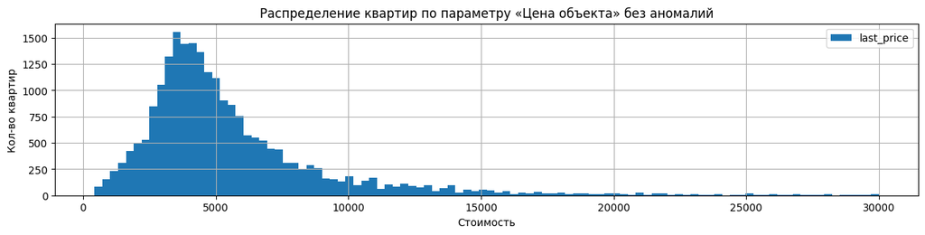

```python
describe_info(data.last_price)

plt.title('Распределение квартир по параметру «Цена объекта» без аномалий')
plt.xlabel('Стоимость')
plt.ylabel('Кол-во квартир');
```

**Вывод по параметру:**

Удалено около 0,53% от исходных данных.

Теперь стоимость квартир находится от 430 тыс. до 30 млн. рублей. Медиана находится на уровне 4 млн. 600 тыс. рублей.

### 3.1.9. Параметр «Расстояние до центра города»

```
Минимальное, максимальное и среднее значение:
```

```
count    17311.000000
mean     14446.386171
std       8535.257601
min        208.000000
25%       9764.500000
50%      13252.000000
75%      16431.000000
max      65968.000000
Name: city_centers_nearest, dtype: float64
```

```
Медианное значение:
```

```
13252.0
```

```
Общее количество строк:
```

```
22676
```

```
График:
```

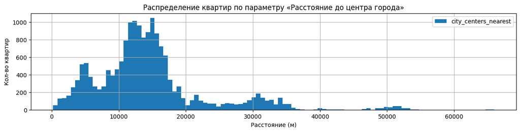

```python
describe_info(data.city_centers_nearest)

plt.title('Распределение квартир по параметру «Расстояние до центра города»')
plt.xlabel('Расстояние (м)')
plt.ylabel('Кол-во квартир');
```

В целом, все выглядит нормально, но интересен всплеск объявлений на расстоянии 50 километров. Рассмотрим все объекты, которые находятся на расстоянии более 40 километров.

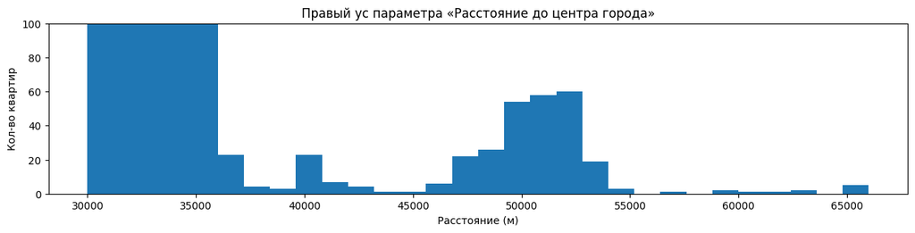

```python
data.hist(column = 'city_centers_nearest', bins = 30, figsize = (15,3), range = (30000,66000), grid=False)
plt.title('Правый ус параметра «Расстояние до центра города»')
plt.xlabel('Расстояние (м)')
plt.ylabel('Кол-во квартир')
plt.ylim(0, 100);
```

```python
data.query('city_centers_nearest > 40000')[['locality_name']].value_counts()
```

```
locality_name
Ломоносов             120
Кронштадт              89
Петергоф               38
Зеленогорск            22
Красное Село            7
поселок Молодежное      5
поселок Репино          4
Сестрорецк              2
dtype: int64
```

```python
data.query('city_centers_nearest > 63000')[['locality_name']].value_counts()
```

```
locality_name
поселок Молодежное    5
dtype: int64
```

Всё в порядке, все населенные пункты действительно находятся на указанном от центра расстоянии.

**Вывод по параметру:**

Кажется, с данными всё в порядке. Ближайшая квартира к центру находится в 208 метрах от центра, самая дальняя — в 65 километрах в поселке Молодежное.

### 3.1.10. Параметр «Расстояние до ближайшего парка»

```
Минимальное, максимальное и среднее значение:
```

```
count    7537.000000
mean      494.602627
std       343.767398
min         1.000000
25%       289.000000
50%       456.000000
75%       616.000000
max      3190.000000
Name: parks_nearest, dtype: float64
```

```
Медианное значение:
```

```
456.0
```

```
Общее количество строк:
```

```
22676
```

```
График:
```

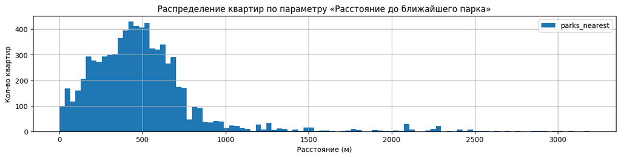

```python
describe_info(data.parks_nearest)

plt.title('Распределение квартир по параметру «Расстояние до ближайшего парка»')
plt.xlabel('Расстояние (м)')
plt.ylabel('Кол-во квартир');
```

Рассмотрим значения в 1 метр. Вряд ли есть дом, расположенный непосредственно в парке. Изучим квартиры, находящиеся до 10 метров до парка.

```python
data.query('parks_nearest < 10')[['total_area', 'living_area', 'kitchen_area', 'ceiling_height', 'rooms',  'floors_total',
                                  'floor', 'last_price', 'days_exposition', 'locality_name', 'parks_nearest']]
```

|  | total_area | living_area | kitchen_area | ceiling_height | rooms | floors_total | floor | last_price | days_exposition | locality_name | parks_nearest |
| --- | --- | --- | --- | --- | --- | --- | --- | --- | --- | --- | --- |
| 2527 | 60.3 | 28.00 | 7.9 | 2.5 | 2 | 5 | 2 | 4690.00 | 146 | Кронштадт | 9.0 |
| 9344 | 28.1 | 17.00 | 5.6 | 2.5 | 1 | 9 | 1 | 3000.00 | 440 | Санкт-Петербург | 7.0 |
| 11949 | 44.0 | 30.00 | 7.0 | 2.6 | 2 | 9 | 7 | 4500.00 | 82 | Санкт-Петербург | 3.0 |
| 14624 | 45.4 | 28.43 | 6.9 | NaN | 2 | 9 | 2 | 3770.00 | 42 | Санкт-Петербург | 1.0 |
| 20193 | 102.6 | NaN | 17.8 | NaN | 3 | 9 | 3 | 11809.67 | 90 | Санкт-Петербург | 9.0 |
| 22941 | 69.3 | 48.90 | NaN | 3.0 | 1 | 4 | 4 | 10965.00 | 110 | Зеленогорск | 4.0 |

К сожалению, мы не можем проверить достоверность этих данных. Поэтому остается поверить им на слово.

```python
(
    data.query('parks_around3000 == 0 and parks_nearest > 1')
    [['total_area', 'living_area', 'kitchen_area', 'ceiling_height','rooms',  'floors_total', 'floor', 'last_price',
      'days_exposition', 'locality_name', 'parks_around3000', 'parks_nearest']]
)
```

|  | total_area | living_area | kitchen_area | ceiling_height | rooms | floors_total | floor | last_price | days_exposition | locality_name | parks_around3000 | parks_nearest |
| --- | --- | --- | --- | --- | --- | --- | --- | --- | --- | --- | --- | --- |
| 1590 | 70.0 | 37.0 | 10.0 | NaN | 2 | 18 | 13 | 7500.0 | 4 | Санкт-Петербург | 0 | 3064.0 |
| 10959 | 31.1 | 17.7 | 5.5 | NaN | 1 | 5 | 2 | 3000.0 | 234 | Санкт-Петербург | 0 | 3190.0 |
| 19208 | 187.0 | 80.0 | 17.0 | 3.0 | 5 | 2 | 2 | 14950.0 | 49 | Санкт-Петербург | 0 | 3013.0 |
| 19430 | 30.5 | 16.5 | 5.5 | 2.6 | 1 | 5 | 1 | 3900.0 | 176 | Санкт-Петербург | 0 | 3190.0 |

**Вывод по параметру:**

Ближайшая к парку квартира, вероятно, находится прямо в парке. А самая удалённая расположена в трёх километрах от него.

### 3.1.11. Параметр «Дата публикации объявления»

Рассмотрим за какой период публиковались объявления.

```python
data.first_day_exposition.agg({'min','max'})
```

```
min   2014-11-27
max   2019-05-03
Name: first_day_exposition, dtype: datetime64[ns]
```

Посмотрим, как объявления распределяются по месяцам за все годы.

```python
data.public_month.value_counts()
```

```
2     2529
3     2477
4     2274
11    2268
10    2041
9     1906
6     1682
8     1665
7     1614
12    1572
1     1436
5     1212
Name: public_month, dtype: int64
```

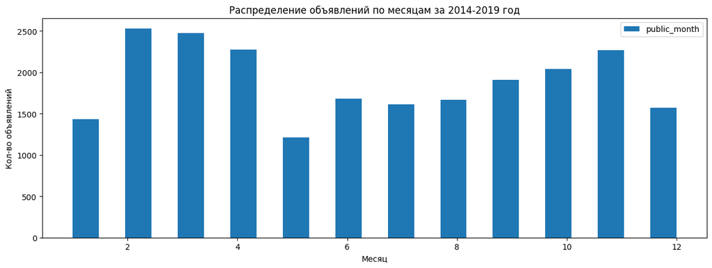

```python
data.plot(y = 'public_month', kind = 'hist', bins = 23, figsize = (15,5));

plt.title('Распределение объявлений по месяцам за 2014-2019 год')
plt.xlabel('Месяц')
plt.ylabel('Кол-во объявлений');
```

Рассмотрим, как данные распределены по годам и как это влияет на показатели. Для удобства создадим переменные с данными за каждый год.

```python
years = [2014, 2015, 2016, 2017, 2018, 2019]
for year in years:
    globals()["date_" + str(year)] = data[data['first_day_exposition'].dt.year == year]
```

```python
for year in years:
    print(f"За {year} год было размещено {globals()['date_' + str(year)].shape[0]} объявлений")
```

```
За 2014 год было размещено 125 объявлений
За 2015 год было размещено 1098 объявлений
За 2016 год было размещено 2633 объявлений
За 2017 год было размещено 7840 объявлений
За 2018 год было размещено 8215 объявлений
За 2019 год было размещено 2765 объявлений
```

Рассмотрим как распределяются публикации объявлений по месяцам в каждый год.

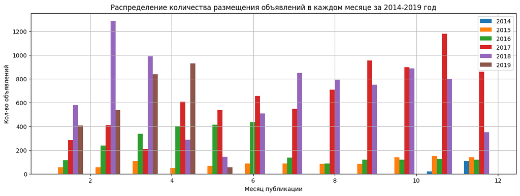

```python
plt.figure(figsize=(15, 5))
plt.hist(
    [
        date_2014['public_month'],
        date_2015['public_month'],
        date_2016['public_month'],
        date_2017['public_month'],
        date_2018['public_month'],
        date_2019['public_month']
    ],
    12,
    alpha=1,
    label=['2014', '2015', '2016', '2017', '2018', '2019']
)

plt.title('Распределение количества размещения объявлений в каждом месяце за 2014-2019 год')
plt.xlabel('Месяц публикации')
plt.ylabel('Кол-во объявлений')

plt.legend()
plt.grid(linestyle='-')
plt.show()
```

В идеале было бы провести исследование только по данным за 2016–2018 годы. Данные за 2014 год точно можно исключить.

Для сравнения по месяцам, следует исключать 2019 год.

```python
data = data.drop(data[data['public_year'] == 2014].index)
```

Посмотрим распределение публикаций объявлений по месяцам без учета 2014 года.

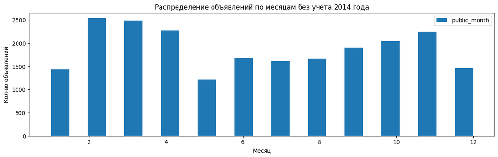

```python
data.plot(y = 'public_month', kind = 'hist', bins = 23, figsize = (15,4))

plt.title('Распределение объявлений по месяцам без учета 2014 года')
plt.xlabel('Месяц')
plt.ylabel('Кол-во объявлений');
```

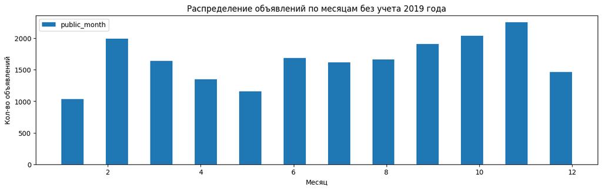

```python
data.query('public_year != 2019').plot(y = 'public_month', kind = 'hist', bins = 23, figsize = (15,4))

plt.title('Распределение объявлений по месяцам без учета 2019 года')
plt.xlabel('Месяц')
plt.ylabel('Кол-во объявлений');
```

Рекорды марта и апреля утратили своё значение, и теперь в лидерах февраль, октябрь и ноябрь. Мы не можем удалить почти три тысячи объявлений за 2019 год, но будем учитывать их влияние при анализе данных, связанных с временными показателями.

Интересно, что самый короткий месяц в году (февраль) оказался в числе лидеров. Вероятно, это типичная ситуация для рынка. После января наблюдается значительный рост количества размещённых объявлений, который снижается к майским праздникам, поскольку начинается сезон сдачи и продажи квартир. Похоже, что таких сезонов в году два — в феврале/марте и сентябре/ноябре.

Посмотрим распределение публикации объявлений по дням недели за всё время.

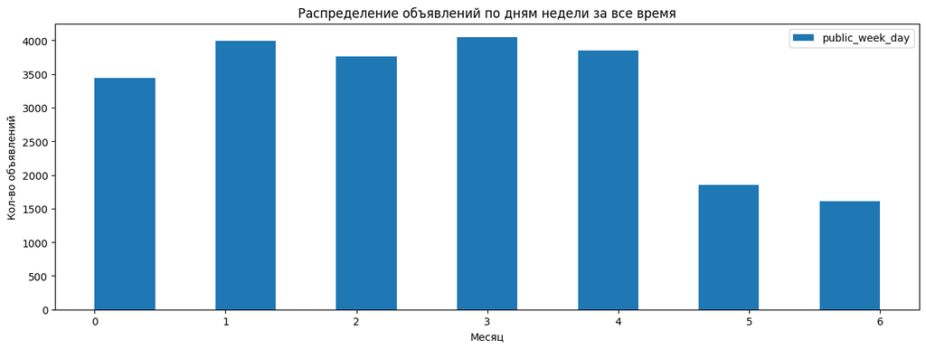

```python
data.plot(y = 'public_week_day', kind = 'hist', bins = 13, figsize = (15,5))

plt.title('Распределение объявлений по дням недели за все время')
plt.xlabel('Месяц')
plt.ylabel('Кол-во объявлений');
```

Выходные не пользуются большой популярностью среди тех, кто размещает объявления. Больше всего объявлений появляется в будние дни. Возможно, это связано с активностью риелторов и агентств недвижимости, а в выходные размещают объявления только собственники.

Также мы создадим сводную таблицу, в которой будет показано, сколько объявлений публиковалось в каждом месяце по сравнению с предыдущим годом.

```python
data.pivot_table(index='public_year', columns='public_month', values='total_images', aggfunc='count')
```

| public_month public_year | 1 | 2 | 3 | 4 | 5 | 6 | 7 | 8 | 9 | 10 | 11 | 12 |
| --- | --- | --- | --- | --- | --- | --- | --- | --- | --- | --- | --- | --- |
| 2015 | 54.0 | 56.0 | 107.0 | 49.0 | 64.0 | 85.0 | 88.0 | 83.0 | 84.0 | 140.0 | 148.0 | 140.0 |
| 2016 | 116.0 | 239.0 | 334.0 | 402.0 | 412.0 | 433.0 | 134.0 | 85.0 | 117.0 | 118.0 | 126.0 | 117.0 |
| 2017 | 284.0 | 411.0 | 208.0 | 606.0 | 536.0 | 655.0 | 545.0 | 706.0 | 954.0 | 898.0 | 1179.0 | 858.0 |
| 2018 | 577.0 | 1287.0 | 989.0 | 288.0 | 144.0 | 509.0 | 847.0 | 791.0 | 751.0 | 885.0 | 796.0 | 351.0 |
| 2019 | 405.0 | 536.0 | 839.0 | 929.0 | 56.0 | NaN | NaN | NaN | NaN | NaN | NaN | NaN |

**Вывод по параметру:**

Удалено около 0.53% от исходных данных.

Все параметры были изучены, аномалии при возможности устранены.

Посмотрим еще раз на обновленную сводную таблицу значений параметров и убедимся в том, что количество аномалий в данных минимально, а сами данные готовы для исследования.

```python
(
    data[['total_area', 'living_area', 'kitchen_area', 'ceiling_height', 'rooms',  'floors_total', 'floor',
          'last_price', 'days_exposition']]
    .apply (['count', 'min', 'max', 'median'])
    .style.format("{:,.2f}")
)
```

|  | total_area | living_area | kitchen_area | ceiling_height | rooms | floors_total | floor | last_price | days_exposition |
| --- | --- | --- | --- | --- | --- | --- | --- | --- | --- |
| count | 22,551.00 | 20,762.00 | 20,418.00 | 13,746.00 | 22,551.00 | 22,551.00 | 22,551.00 | 22,551.00 | 22,551.00 |
| min | 20.00 | 8.00 | 5.00 | 2.50 | 0.00 | 1.00 | 1.00 | 430.00 | 0.00 |
| max | 200.00 | 99.90 | 40.00 | 4.00 | 7.00 | 35.00 | 33.00 | 30,000.00 | 1,497.00 |
| median | 51.00 | 30.00 | 9.00 | 2.65 | 2.00 | 9.00 | 4.00 | 4,595.00 | 72.00 |

Данные приведены в норму. В ходе исследования аномалий удалено около 4,67% от изначальных данных, что является близким к оптимальному уровню потерь данных. Общее количество записей — 22 551.